# Grover's Search Algorithm

In this tutorial, we introduce the search problem and present Grover's search algorithm, a quantum algorithm that solves the search problem. The search problem itself has several variants, and in this tutorial we focus on the unstructured search setting. Grover's algorithm has an important property in this setting. It provides a provable quadratic speedup over the best possible classical approach in the oracle model, with Grover's search scaling as $\mathcal{O}(\sqrt{N})$ and the optimal classical method scaling as $\mathcal{O}(N)$.

In this tutorial, we begin by restricting our focus to the case where there is a single marked target in the search database. We first provide an analysis that describes how the probability of success evolves during one iteration of Grover's algorithm. To generalize this analysis, we introduce several mathematical tools, such as invariant subspaces, closure under composition, direct sums, block matrix representations with respect to a direct sum, and the ideas of restriction and compression. These concepts allow us to show that Grover's algorithm effectively operates within a two dimensional subspace. This reduction gives a geometric framework for understanding Grover's algorithm, since the Grover iteration can then be viewed as the combination of two reflections that produce a rotation in this subspace.

This framework allows us to analyze the behaviour of the algorithm for different possibilities regarding the number of marked states. These cases include no marked states, exactly one marked state, several marked states, and the situation where all items in the search space are marked. To understand these geometric analyses and their generalization, a substantial amount of mathematical groundwork need to be developed.

We then briefly outline how the number of solutions can be determined when it is not provided. After that, we discuss the optimality of quantum algorithms for the search problem and show that Grover's algorithm is optimal with a complexity of $\Theta(\sqrt{N})$. The lower bound of $\Omega(\sqrt{N})$ has important theoretical implications, since it establishes a fundamental limit on the amount of speedup that quantum computers can achieve for unstructured search.

Lastly, we implement Grover's algorithm in Qiskit and PennyLane. We discuss different ways to construct the Grover oracle and the diffuser operator, either by using built-in methods or by defining custom circuits, and we analyze the probabilistic evolution of the algorithm through its iterations.

1. Introduction
2. Problem Statement
3. Grover's Oracle
4. Grover's Algorithm
5. Correctness of Grover's Algorithm
6. Algebraic Correctness of Grover's Algorithm for One Iteration
7. Grover's Algorithm from the Geometric Perspective
8. Optimal Number of Iterations
9. Grover's Algorithm Beyond the Single-Marked Case
10. Estimating the Number of Solutions
11. Optimality of Query Complexity
12. Comparison of Query Complexity of Classical and Quantum Methods
13. Grover's Algorithm: Implementation and State Evolution in Qiskit and PennyLane
14. Conclusion

### Appendices

15. Appendix 1: Biography
16. Appendix 2: References and Suggested Readings

### Introduction

Suppose we are searching an unstructured list of $N$ items for a specific target. While $N$ can be any positive integer, it is often convenient to assume that $N$ is a power of two, written as $N = 2^n$. If this is not the case, additional elements can be padded so that the total number of items becomes $2^n$. Classically, this requires on average about $\tfrac{N}{2}$ queries to find the desired item. In the quantum setting, however, by exploiting superposition and interference, the same task can be accomplished in roughly $\sqrt{N} = N^{1/2}$ queries. This quadratic speedup over classical algorithms is achieved through Grover's search algorithm. In what follows, we first define the problem statement and then explain how Grover’s algorithm addresses the *unstructured search problem*.

### Problem Statement

Let $f : \{0,1\}^n \rightarrow \{0,1\}$ be a classical [Boolean function](https://en.wikipedia.org/wiki/Boolean_function) on $n$-bit inputs. The *search problem* is to find a string $x_0 \in \{0,1\}^n$ such that $f(x_0) = 1$, or to conclude that no such $x_0$ exists, in which case $f(x) = 0$ for all $x$.

We treat $f$ as a black-box function and make no assumptions about any underlying structure. The description above is the decision version of the problem, but it can also be stated as a promise problem where a marked element satisfying $f(x_0) = 1$ is guaranteed to exist. It may also involve a set of marked elements $\Omega \subseteq \{0,1,\ldots,N\}$, where the size of $\Omega$ may be one, more than one, or zero. In this tutorial, we allow the flexibility to discuss these formulations together, since the underlying analysis is the same and only the details of the solution differ. These formulations are closely related and are often interchangeable in the study of Grover's algorithm.

### Grover's Oracle

Grover's algorithm makes use of an oracle $U_f$ that encodes the marked element $x_0$ by flipping its phase when $f(x) = 1$ and leaving all other states unchanged. In other words,

$$ U_f |x\rangle |a\rangle = |x\rangle |a \oplus f(x)\rangle = \begin{cases} |x\rangle |a\rangle & \text{if } f(x) = 0,\\ |x\rangle |a \oplus 1\rangle & \text{if } f(x) = 1. \end{cases} $$

The oracle $U_f$ here requires an auxiliary qubit. This does not directly flip the phase of $|x\rangle$. However, when the auxiliary qubit is initialized in the state $|-\rangle$, the action of $U_f$ induces a phase flip on the marked state. In this case, $U_f|x\rangle|-\rangle = (-1)^{f(x)} |x\rangle|-\rangle$, which is equivalent to the phase oracle $$ U_{\omega} = I - 2 \, |\omega\rangle\langle\omega|, $$ yielding $$ U_\omega |x\rangle = \begin{cases} - |x\rangle & \text{if } x = \omega,\\ |x\rangle & \text{if } x \neq \omega, \end{cases} $$ where $\omega$ is the marked state.

Next we state Grover's algorithm and then discuss its correctness and analyze how the probability of success evolves throughout the algorithm.

### Grover's Algorithm

Next we will describe the algorithm first and then go over its details and correctness:

1. **Initialization.**

Prepare an $n$-qubit register in the uniform superposition over all $N = 2^n$ basis states, $$ |s\rangle = H^{\otimes n} |0\rangle^{\otimes n} = \frac{1}{\sqrt{N}} \sum_{x=0}^{N-1} |x\rangle. $$

2. **Grover iteration.**  
   Apply the Grover iteration $k_{\text{opt}}$ times ($k_{\text{opt}}$ to be determined).
   1. **Oracle.**  
      Apply $U_\omega$ so that every marked basis state acquires a phase of $-1$ while unmarked states remain unchanged.
   2. **Diffusion step.**
      Apply the Grover diffusion operator $$ U_s = 2 |s\rangle\langle s| - I, \qquad |s\rangle = \frac{1}{\sqrt{N}} \sum_{x=0}^{N-1} |x\rangle. $$ This operator performs an inversion of amplitudes about their mean.
      It can also be expressed as $$ U_s = H^{\otimes n} \left( 2|0\rangle\langle 0| - I \right) H^{\otimes n}. $$
3. **Measurement.**  
   Measure the final state in the computational basis and classically verify the result.

**Remarks**

- **Two equivalent views of the diffusion step**  
  "Inverting amplitudes about the mean" and "applying a conditional phase shift of $-1$ to all states except $|0\rangle$" are equivalent descriptions of the same operation. (They differ only by surrounding layers of Hadamard gates: applying Hadamards before and after the phase operator $(2|0\rangle\langle0| - I)$ transforms it into $(2|s\rangle\langle s| - I)$, which performs the inversion about the mean. We will explain this equivalence later.)
- **Optimal number of iterations**

When there is exactly one marked element in the database, the optimal number of Grover iterations satisfies
$$ k_{\text{optimal}} \approx \frac{\pi}{4}\sqrt{N}. $$

If there are $M$ marked items among $N$ total, the optimal number of Grover iterations satisfies
$$t_{\text{optimal}} \approx \left\lfloor \frac{\pi}{4}\sqrt{\frac{N}{M}} \right\rfloor.$$
We will derive this formula later. When $M$ is unknown, one can use quantum counting or schedule-based strategies to achieve near-optimal performance.

- **The Operators $U_\omega = I - 2|\omega\rangle\langle \omega|$ and $U_s = 2 |s\rangle \langle s | - I$ are unitaries**

Since $U_\omega$ and $U_s$ are quantum gates, they must be unitary. However, it is not immediately clear that these operators are unitary. Operators of the form $R = I - 2P$, where $P$ is a projector, are reflection operators, and such operators are unitary. Hence both $$ U_\omega = I - 2|\omega\rangle\langle\omega| \qquad\text{and}\qquad U_s = 2|s\rangle\langle s| - I $$ are reflections and therefore unitaries.

We first show why operators of this form are unitary, and then show why they are reflections.

Let $P$ be a projector of the form $P = |v\rangle\langle v|$ where $\|v\| = 1$. A projector satisfies:

1. $P^2 = P$ which means it is idempotent
2. $P^\dagger = P$ which means it is Hermitian

Our goal is to show that $R = I - 2P$ is unitary, that is $R^\dagger R = I$. We first compute $R^\dagger$:

$$ R^\dagger = (I - 2P)^\dagger = I^\dagger - 2P^\dagger = I - 2P = R, $$

since $I^\dagger = I$ and $P^\dagger = P$.

Now we compute $RR^\dagger$. Since $R^\dagger = R$, we have $RR^\dagger = R^2$. Thus,

$$ R^2 = (I - 2P)^2 = I - 4P + 4P^2. $$

Using the fact that $P^2 = P$, this becomes

$$ R^2 = I - 4P + 4P = I. $$

Therefore $R^\dagger R = I$, which shows that $R$ is unitary.

Next, we argue that $R$ is a reflection operator. In this context, the reflection is about a plane or hyperplane containing the origin. This type of reflection is known as a [*Householder reflection*](https://en.wikipedia.org/wiki/Householder_transformation), named after mathematician Alston Scott Householder.

A linear operator $R$ on a Hilbert space is a reflection if:

1. $R$ is unitary.
2. $R$ is Hermitian.
3. $R^2 = I$.
4. There exists a unit vector $|v\rangle$ such that  
   $R|v\rangle = -|v\rangle$ and  
   $R|\phi\rangle = |\phi\rangle$ for all $|\phi\rangle$ orthogonal to $|v\rangle$.

We have already shown that $R = I - 2P$ is unitary, Hermitian ($R^\dagger = R$), and satisfies $R^2 = I$.  
Since $P = |\omega\rangle\langle\omega|$ projects onto the marked state, the operator

$$ U_\omega = I - 2|\omega\rangle\langle\omega| $$

flips the marked vector and leaves every vector orthogonal to it unchanged. Therefore, $U_\omega$ is a reflection across the hyperplane orthogonal to the marked state.

Similarly,

$$ U_s = 2|s\rangle\langle s| - I $$

is a reflection across the one dimensional subspace spanned by $|s\rangle$. This reflection is exactly what implements the "inversion about the mean" step in Grover's algorithm.

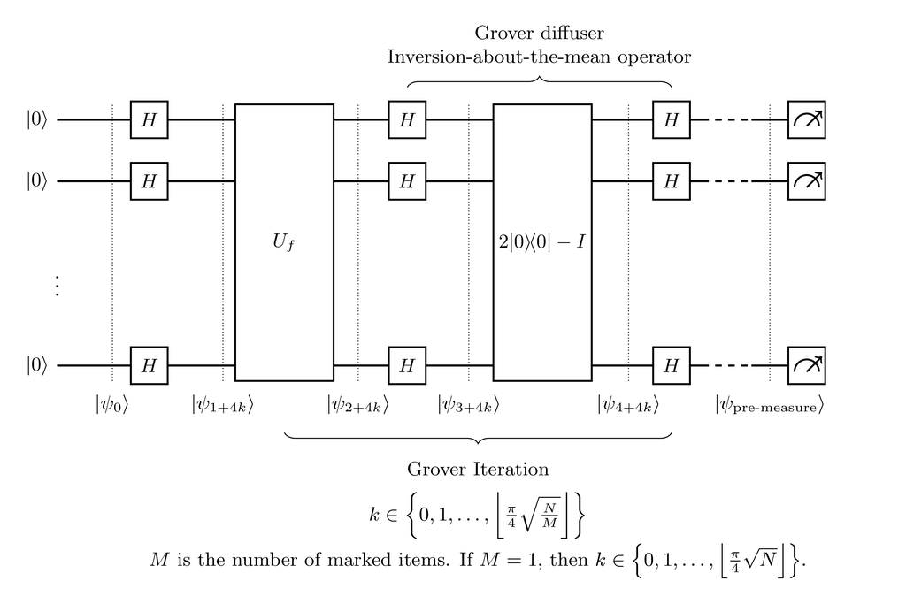

### Correctness of Grover's Algorithm

We now examine the correctness of Grover's algorithm and verify that the Grover iteration indeed amplifies the amplitude of the marked state.

Initialization:

$$ |\psi_0\rangle = |0\rangle^{\otimes n} $$

$$ |\psi_1\rangle = H^{\otimes n}|\psi_0\rangle = \frac{1}{\sqrt{N}} \sum_{x=0}^{N-1} |x\rangle. $$

Let the unique marked item be $|\omega\rangle$. The phase oracle

$$ U_\omega = I - 2|\omega\rangle\langle\omega| $$

acts on the uniform superposition state by flipping only the amplitude of the marked basis vector:

$$ U_\omega |\psi_1\rangle = \frac{1}{\sqrt{N}} \left( -|\omega\rangle + \sum_{x \neq \omega} |x\rangle \right). $$

There are two approaches to establishing the correctness of Grover's iteration $G = U_s U_\omega$: an algebraic one and a geometric one. The algebraic approach expands every step explicitly and shows how the amplitudes evolve. The geometric approach gives a more intuitive interpretation: the algorithm performs a rotation in a two-dimensional subspace. We begin with the algebraic derivation of a single Grover iteration.

### Algebraic Correctness of Grover's Algorithm for One Iteration

**Grover Oracle $U_\omega$ on the uniform superposition**

Let $$ |s\rangle=\frac{1}{\sqrt{N}}\sum_{x=0}^{N-1}|x\rangle,\qquad U_\omega = I - 2|\omega\rangle\langle\omega|. $$

We use linearity and the projector action to compute $U_\omega|s\rangle$: $$ U_\omega|s\rangle = (I - 2|\omega\rangle\langle\omega|)\,|s\rangle = |s\rangle - 2\,|\omega\rangle\langle\omega|s\rangle. $$

To compute the overlap $\langle \omega | s \rangle$, we use the inner product:

$$ \langle \omega | s \rangle = \frac{1}{\sqrt{N}}\sum_{x=0}^{N-1} \langle \omega | x \rangle. $$

Since the computational basis $\{|x\rangle\}$ is orthonormal, we have

$$ \langle \omega | x \rangle = \begin{cases} 1, & x = \omega, \\ 0, & x \neq \omega. \end{cases} $$

Therefore, only one term in the sum survives:

$$ \langle \omega | s \rangle = \frac{1}{\sqrt{N}}. $$

We obtain the closed form $$ \boxed{|\psi_2\rangle = U_\omega|s\rangle = |s\rangle - \frac{2}{\sqrt{N}}\,|\omega\rangle = \frac{1}{\sqrt{N}}\!\left(-|\omega\rangle+\!\!\sum_{x\neq\omega}\!|x\rangle\right).\,} $$

Note, if $|r\rangle = \frac{1}{\sqrt{N - 1}} \sum_{x \neq \omega} |x\rangle$ and $|s\rangle = \sin\theta \, |\omega\rangle + \cos\theta \, |r\rangle$ with $\sin\theta = \tfrac{1}{\sqrt{N}}$, then

$$ |\psi_2\rangle = U_\omega |s\rangle = - \sin\theta \, |\omega\rangle + \cos\theta \, |r\rangle. $$

Framing it in this way will help us prepare for the geometric view of Grover's algorithm. While we are not going into its details right now, it is useful to keep this viewpoint in mind.

**Diffusion operator and its effect on the post-oracle state**

Let $$ |s\rangle=\frac{1}{\sqrt{N}}\sum_{x=0}^{N-1}|x\rangle,\qquad U_s = 2|s\rangle\langle s| - I. $$

From the previous step (oracle applied to the uniform superposition), $$ |\psi_2\rangle \;=\; U_\omega|s\rangle = \frac{1}{\sqrt{N}}\!\left(-|\omega\rangle+\!\!\sum_{x\neq\omega}\!|x\rangle\right). $$

We now compute $U_s|\psi_2\rangle$ algebraically. By definition, $$ U_s|\psi_2\rangle = \bigl(2|s\rangle\langle s| - I\bigr)|\psi_2\rangle = 2\,\langle s|\psi_2\rangle\,|s\rangle \;-\; |\psi_2\rangle $$

First, compute the overlap $\langle s|\psi_2\rangle$ and use $\langle s|=\frac{1}{\sqrt{N}}\sum_{y=0}^{N-1}\langle y|$: $$ \langle s|\psi_2\rangle = \frac{1}{\sqrt{N}}\sum_{y=0}^{N-1}\langle y|\;\cdot\;\frac{1}{\sqrt{N}} \left(-|\omega\rangle+\sum_{x\neq\omega}|x\rangle\right) = \frac{1}{N}\left(-1 + (N-1)\right) = \frac{N-2}{N}. $$

Apply $U_s$ in projector form $$ \begin{aligned} U_s|\psi_2\rangle = \bigl(2|s\rangle\langle s| - I\bigr)|\psi_2\rangle = 2\,\langle s|\psi_2\rangle\,|s\rangle \;-\; |\psi_2\rangle = \frac{2(N-2)}{N}\,|s\rangle \;-\; |\psi_2\rangle. \end{aligned} $$

Substitute $|s\rangle$ and $|\psi_2\rangle$ and read off amplitudes:

$$ \begin{aligned} U_s|\psi_2\rangle &= \frac{2(N-2)}{N}\cdot\frac{1}{\sqrt{N}}\sum_{y=0}^{N-1}|y\rangle \;-\; \frac{1}{\sqrt{N}}\left(-|\omega\rangle+\sum_{x\neq\omega}|x\rangle\right) \\ &= \left[ \frac{2(N-2)}{N} \cdot \frac{1}{\sqrt{N}} + \frac{1}{\sqrt{N}} \right] |\omega \rangle + \left[ \frac{2(N-2)}{N} \cdot \frac{1}{\sqrt{N}} - \frac{1}{\sqrt{N}} \right] \sum\limits_{x \neq \omega} |x\rangle \end{aligned} $$

- Coefficient of the marked basis state $|\omega\rangle$: $$ a'_\omega = \frac{2(N-2)}{N}\cdot\frac{1}{\sqrt{N}} \;+ \frac{1}{\sqrt{N}} = \frac{3N-4}{N\sqrt{N}}. $$
- Coefficient of each unmarked $|x\neq\omega\rangle$: $$ a'_x = \frac{2(N-2)}{N}\cdot\frac{1}{\sqrt{N}} \;-\;\frac{1}{\sqrt{N}} = \frac{N-4}{N\sqrt{N}}. $$

Final algebraic form $$ \boxed{~ |\psi_3 \rangle = U_s|\psi_2\rangle = \frac{3N-4}{N\sqrt{N}}\,|\omega\rangle \;+\; \frac{N-4}{N\sqrt{N}}\sum_{x\neq\omega}|x\rangle.~} $$

From the initial uniform superposition, the amplitude of the marked state $|\omega\rangle$ has grown from $\frac{1}{\sqrt{N}}$ to $\frac{3N - 4}{N\sqrt{N}}$. The ratio is

$$ \frac{\frac{3N - 4}{N\sqrt{N}}}{\frac{1}{\sqrt{N}}} = \frac{3N - 4}{N}. $$

Note that $\lim\limits_{N \rightarrow \infty} \frac{3N - 4}{N} = 3$. Thus, the amplitude of the marked state almost triples in one iteration. Equivalently, the probability grows from $\frac{1}{N}$ to approximately $\frac{9}{N}$ for large $N$.

### Grover's Algorithm from the Geometric Perspective

$\DeclareMathOperator{\span}{span}$

Next we provide the same argument geometrically. The geometric perspective generalizes Grover's iteration naturally, and it shows how Grover's algorithm divides the space into a dichotomy of good and bad solutions, which is closely related to quantum amplitude amplification. We will show that the geometric picture matches the algebraic results for $|\psi_2\rangle$ and $|\psi_3\rangle$.

Recall that $|\psi_1\rangle = |s\rangle = \frac{1}{\sqrt{N}} \sum_{x = 0}^{N - 1} |x\rangle$, and we have already shown, by algebraic argument, that

$$ U_\omega |\psi_1\rangle = \frac{1}{\sqrt{N}} \left( -|\omega\rangle + \sum_{x \neq \omega} |x\rangle \right). $$

Define the normalized vector $$ |r\rangle \coloneqq \frac{1}{\sqrt{N - 1}} \sum_{x \neq \omega} |x\rangle, $$ so that $\langle r | \omega \rangle = 0$ and $\{\,|\omega\rangle, |r\rangle\,\}$ forms an orthonormal basis for the 2D Grover plane.

Let $$ \mathcal{S} = \operatorname{span}\{\,|\omega\rangle, |r\rangle\,\}, \qquad \mathcal{S}^{\perp} = \{\,|v\rangle \in \mathbb{C}^{N} : \langle v | u \rangle = 0 \text{ for all } |u\rangle \in \mathcal{S}\,\}. $$

We begin by showing that $U_\omega$ and $U_s$ preserve the subspaces $\mathcal{S}$ and $\mathcal{S}^\perp$. Consequently, their combined action can be analyzed entirely within the two-dimensional subspace $\mathcal{S}$.

We will establish the following results:

1. $\mathcal{S}$ and $\mathcal{S}^\perp$ are invariant under $U_\omega$.
2. $\mathcal{S}$ and $\mathcal{S}^\perp$ are invariant under $U_s$.
3. $\mathcal{S}$ and $\mathcal{S}^\perp$ are invariant under the Grover iteration $G = U_s U_\omega$.

For clarity, we will define the notion of invariant.

**Definition - Invariant**

Let $A$ be a linear operator acting on a vector space $V$, and let $\mathcal{S} \subseteq V$ be a subspace. We say that $\mathcal{S}$ is *invariant* under $A$ if and only if
$$ \forall\, |s\rangle \in \mathcal{S},\quad A|s\rangle \in \mathcal{S}. $$

To prove the above theorems, we prove the following two lemmas.

**Lemma 1 - Invariance of $\mathcal{S}$ and $\mathcal{S}^\perp$ under $U_\omega$**

The action of $U_\omega$ preserves $\mathcal{S}$ and $\mathcal{S}^\perp$. In other words, $$ U_\omega(\mathcal{S}) \subseteq \mathcal{S}, \qquad U_\omega(\mathcal{S}^\perp) \subseteq \mathcal{S}^\perp, $$ where $U_\omega = I - 2|\omega\rangle\langle\omega|$.

**Proof** *(click to expand / collapse)**

Let $|\psi\rangle = \alpha|\omega\rangle + \beta|r\rangle \in \mathcal{S}$. Then $$ \begin{aligned} U_\omega|\psi\rangle &= (I - 2|\omega\rangle\langle\omega|)(\alpha|\omega\rangle + \beta|r\rangle) \\ &= \alpha|\omega\rangle + \beta|r\rangle - 2\alpha|\omega\rangle \\ &= -\alpha|\omega\rangle + \beta|r\rangle \in \mathcal{S}. \end{aligned} $$ Thus $U_\omega(\mathcal{S}) \subseteq \mathcal{S}$.

For any $|v\rangle \in \mathcal{S}^\perp$, we have $\langle \omega|v\rangle = 0$, so $$ U_\omega|v\rangle = (I - 2|\omega\rangle\langle\omega|)|v\rangle = |v\rangle \in \mathcal{S}^\perp. $$ Hence, $\mathcal{S}^\perp$ is also invariant under $U_\omega$.

**Lemma 2 - Invariance of $\mathcal{S}$ and $\mathcal{S}^\perp$ under $U_s$**

The action of $U_s$ preserves $\mathcal{S}$ and $\mathcal{S}^\perp$. In other words, $$ U_s(\mathcal{S}) \subseteq \mathcal{S}, \qquad U_s(\mathcal{S}^\perp) \subseteq \mathcal{S}^\perp, $$ where $U_s = 2|s\rangle\langle s| - I$ and $|s\rangle \in \mathcal{S}$.

**Proof** *(click to expand / collapse)**

(1) Let $|\psi\rangle \in \mathcal{S}$. Since $|s\rangle \in \mathcal{S}$ and $\mathcal{S}$ is a subspace, $$ U_s|\psi\rangle = (2|s\rangle\langle s| - I)|\psi\rangle = 2\langle s|\psi\rangle\,|s\rangle - |\psi\rangle \;\in\; \mathcal{S}. $$ Hence $U_s(\mathcal{S}) \subseteq \mathcal{S}$.

(2) Let $|v\rangle \in \mathcal{S}^\perp$. Because $|s\rangle \in \mathcal{S}$, we have $\langle s|v\rangle = 0$. Therefore, $$ U_s|v\rangle = (2|s\rangle\langle s| - I)|v\rangle = -\,|v\rangle \;\in\; \mathcal{S}^\perp. $$ Thus $U_s(\mathcal{S}^\perp) \subseteq \mathcal{S}^\perp$ as well.

**Theorem - Invariance of $\mathcal{S}$ and $\mathcal{S}^\perp$ under the Grover operator**

Let $G \coloneqq U_s U_\omega$, where $$ U_\omega = I - 2|\omega\rangle\langle\omega|, \qquad U_s = 2|s\rangle\langle s| - I, $$ and let $\mathcal{S} = \mathrm{span}\{\,|\omega\rangle, |r\rangle\,\}$ with $\mathcal{S}^\perp$ its orthogonal complement. If $\mathcal{S}$ and $\mathcal{S}^\perp$ are invariant under both $U_\omega$ and $U_s$, then they are also invariant under the Grover operator $G$.

**Proof** *(click to expand / collapse)**

Let $|\psi\rangle \in \mathcal{S}$. By invariance of $\mathcal{S}$ under $U_\omega$ by Lemma 1, we have $U_\omega|\psi\rangle \in \mathcal{S}$. Since $\mathcal{S}$ is also invariant under $U_s$, it follows that $$ G|\psi\rangle = U_s\!\big(U_\omega|\psi\rangle\big) \in \mathcal{S}. $$ Hence $G(\mathcal{S}) \subseteq \mathcal{S}$.

The result of above theorem abstractly follows from the fact that the set of operators that leave a subspace invariant is closed under composition. We just state the general theorem, while the proof remains similar.

**Theorem - Closure of subspace invariance under composition**

Let $\mathcal{S}$ be a subspace of $V$, and let $A,B:V\to V$ be linear operators such that $\mathcal{S}$ is invariant under both $A$ and $B$. Then $\mathcal{S}$ is also invariant under the composition $BA$.

Having established that $\mathcal{S}$ is invariant under $G$, we now state the theorems that justify restricting our attention to the operator $G|_{\mathcal{S}}$. These results show that, in Grover's algorithm, the entire system dynamics can be represented as a 1-qubit unitary acting on the 2-dimensional subspace $\mathcal{S}$ of $\mathcal{H}$.

**Definition - Direct Sum**

Let $V$ be a vector space and let $\mathcal{S}_1, \mathcal{S}_2 \subseteq V$ be subspaces.
We say that $V$ is the direct sum of $\mathcal{S}_1$ and $\mathcal{S}_2$, written $$ V = \mathcal{S}_1 \oplus \mathcal{S}_2, $$ if every vector $v \in V$ can be uniquely expressed as $$ v = s_1 + s_2, \qquad s_1 \in \mathcal{S}_1,\ s_2 \in \mathcal{S}_2, $$ and the two subspaces intersect only at the zero vector, $$ \mathcal{S}_1 \cap \mathcal{S}_2 = \{0\}. $$ This means that $\mathcal{S}_1$ and $\mathcal{S}_2$ together span $V$ and overlap trivially, that is they share the zero vector.

**Remark**

The subspaces in a direct-sum decomposition need not be orthogonal. Orthogonality requires an inner-product structure and is a stronger condition: if, in addition, $$ \langle s_1, s_2 \rangle = 0 \quad \text{for all } s_1 \in \mathcal{S}_1,\ s_2 \in \mathcal{S}_2, $$ then the decomposition is called an *orthogonal direct sum*, written $$ V = \mathcal{S}_1 \oplus^\perp \mathcal{S}_2. $$ Orthogonality implies a direct sum, but not vice versa.

**Definition - Projector**

Let $V$ be a vector space over $\mathbb{R}$ or $\mathbb{C}$, and let $\mathcal{S} \subseteq V$ be a subspace.
A *projector* or *projection operator* onto $\mathcal{S}$ is a linear map $$ P : V \to V $$ such that $$ P^2 = P. $$

The image and kernel of $P$ are complementary subspaces: $$ \mathrm{Im}(P) = \mathcal{S}, \qquad \mathrm{Ker}(P) = \mathcal{T}, $$ so that $$ V = \mathcal{S} \oplus \mathcal{T}. $$

In this case we say that $P$ projects onto $\mathcal{S}$ along $\mathcal{T}$.

**Remark**

$\mathcal{S}$ and $\mathcal{T}$ in a general direct sum decomposition need not be orthogonal.

**Remark**

If $V$ is an inner-product space, we can ask for the additional condition $$ P^\dagger = P, $$ meaning $P$ is self-adjoint (Hermitian).

Then, and only then, $\mathcal{S}$ and $\mathcal{T}$ become orthogonal complements: $$ \mathcal{T} = \mathcal{S}^\perp, $$ and the decomposition becomes $$ V = S \oplus^\perp S^{\perp}. $$

Now $P$ projects orthogonally onto $\mathcal{S}$, and $I-P$ projects orthogonally onto $\mathcal{S}^\perp$.

**Theorem - Block Matrix Representation w.r.t. a Direct Sum**

Let $V$ be a finite-dimensional vector space with a direct-sum decomposition that is not necessarily orthogonal $$ V = \mathcal{S}_1 \oplus \mathcal{S}_2, $$ and let $A: V \to V$ be a linear operator. In any basis adapted to the decomposition $\mathcal{B} = (\mathcal{B}_1, \mathcal{B}_2)$, where $\mathcal{B}_i$ spans $\mathcal{S}_i$, the matrix $A$ has the block form $$ A = \begin{bmatrix} A_{11} & A_{12} \\ A_{21} & A_{22} \end{bmatrix}, $$ where $A_{11}: \mathcal{S}_1 \to \mathcal{S}_1$, $A_{12}: \mathcal{S}_2 \to \mathcal{S}_1$, $A_{21}: \mathcal{S}_1 \to \mathcal{S}_2$, and $A_{22}: \mathcal{S}_2 \to \mathcal{S}_2$.

**Proof** *(click to expand / collapse)**

Since $V=\mathcal{S}_1\oplus\mathcal{S}_2$, every $v\in V$ decomposes uniquely as $v=v_1+v_2$ with $v_i\in\mathcal{S}_i$. Let $P_i : V \to \mathcal{S}_i$ be the projector onto $\mathcal{S}_i$ along the complementary subspace $\mathcal{S}_j$, for $i,j \in \{1,2\}$ with $i \neq j$. These projectors satisfy $$ P_i^2 = P_i, \qquad P_i P_j = 0 \ \text{for } i \neq j, \qquad P_1 + P_2 = I. $$

Then for any $v$, $$ A v = A(P_1+P_2)v = AP_1 v + AP_2 v = (P_1+P_2)AP_1 v + (P_1+P_2)AP_2 v = \sum_{i,j\in\{1,2\}} P_i A P_j v. $$ Thus, as an operator, $$ A = P_1AP_1 \;+\; P_1AP_2 \;+\; P_2AP_1 \;+\; P_2AP_2. $$ Each term $P_iAP_j$ maps $\mathcal{S}_j$ into $\mathcal{S}_i$, so we may define the four linear maps $$ A_{ij}: \mathcal{S}_j \to \mathcal{S}_i, \qquad A_{ij} := P_i A P_j. $$

Now choose a basis $\mathcal{B}=(\mathcal{B}_1,\mathcal{B}_2)$ adapted to the decomposition, so that vectors in $\mathcal{S}_1$ have coordinates $(x,0)$ and vectors in $\mathcal{S}_2$ have coordinates $(0,y)$ relative to $\mathcal{B}$.

Writing $A$ in this basis, the action of $A$ on a generic vector $(x,0)$ (i.e., an element of $\mathcal{S}_1$) produces:

- an $\mathcal{S}_1$-component determined by $A_{11}$, and
- an $\mathcal{S}_2$-component determined by $A_{21}$.

Similarly, the action on $(0,y)\in\mathcal{S}_2$ produces:

- an $\mathcal{S}_1$-component determined by $A_{12}$, and
- an $\mathcal{S}_2$-component determined by $A_{22}$.

Hence, in coordinates relative to the adapted basis $\mathcal{B}$, the matrix of $A$ takes the block form $$ A = \begin{bmatrix} A_{11} & A_{12} \\ A_{21} & A_{22} \end{bmatrix}, $$ with $A_{ij} = P_i A P_j$ denoting the component of $A$ mapping $\mathcal{S}_j$ into $\mathcal{S}_i$ via the projectors $P_i$. This gives the desired block representation.

**Remark**

Equivalently, the block components can be expressed using the projection operators $P_1: V \to \mathcal{S}_1$ and $P_2: V \to \mathcal{S}_2$ associated with the direct-sum decomposition $$ V = \mathcal{S}_1 \oplus \mathcal{S}_2. $$ These satisfy $$ P_1 + P_2 = I, \qquad P_i^2 = P_i, \qquad P_i P_j = 0 \ \text{for } i \neq j. $$ Then the individual blocks of $A$ are given by $$ A_{ij} = P_i A P_j, \qquad i,j \in \{1,2\}. $$ Hence the full operator decomposes as $$ A = P_1 A P_1 + P_1 A P_2 + P_2 A P_1 + P_2 A P_2 = \begin{bmatrix} A_{11} & A_{12} \\ A_{21} & A_{22} \end{bmatrix}. $$

**Corollaries**

- If $\mathcal{S}_1$ is $A$-invariant, then $A_{21}=0$ and $A$ is block upper-triangular.
- If both $\mathcal{S}_1$ and $\mathcal{S}_2$ are $A$-invariant, then $A_{12}=A_{21}=0$ and $A$ is block-diagonal.
- If $A$ is normal, meaning $A A^\dagger = A^\dagger A$, and this includes unitary and Hermitian operators, and if the decomposition satisfies $\mathcal{S}_2 = \mathcal{S}_1^\perp$ in an inner-product space, then both subspaces are invariant under $A$, and the operator admits a block-diagonal representation with respect to $\mathcal{S}_1 \oplus \mathcal{S}_1^\perp$.

**Corollary - Two-Dimensional Reduction of Grover Iteration**

Let $\mathcal{H}$ be the $N$-dimensional Hilbert space spanned by the computational basis states $\{|x\rangle : x \in \{0,1,\dots,N-1\}\}$. Define the two-dimensional subspace $$ \mathcal{S} = \mathrm{span}\{\,|\omega\rangle,\ |r\rangle\,\}, $$ where $$ |r\rangle = \frac{1}{\sqrt{N-1}} \sum_{x \neq \omega} |x\rangle. $$ With respect to the orthogonal decomposition $$ \mathcal{H} = \mathcal{S} \oplus \mathcal{S}^\perp, $$ the Grover operator $G = U_s U_\omega$ is block-diagonal: $$ G = \begin{pmatrix} G|_{\mathcal{S}} & 0 \\[4pt] 0 & G|_{\mathcal{S}^\perp} \end{pmatrix}. $$ Since the initial superposition state $|s\rangle \in \mathcal{S}$, the entire Grover evolution, $$ |s\rangle,\quad G|s\rangle,\quad G^2|s\rangle,\ \dots, $$ remains confined to the two-dimensional subspace $\mathcal{S}$.

**Definition - Restriction and Compression**

Let $\mathcal{H}$ be a Hilbert space and $\mathcal{S} \subset \mathcal{H}$ a subspace with the orthogonal decomposition $$ \mathcal{H} = \mathcal{S} \oplus \mathcal{S}^\perp. $$ Let $G: \mathcal{H} \rightarrow \mathcal{H}$ be a unitary. Furthermore, suppose $\mathcal{S}$ is invariant under $G$. In other words, $G\mathcal{S} \subseteq \mathcal{S}$.

The *restriction* $$ G|_\mathcal{S}: \mathcal{S} \rightarrow \mathcal{S}, \quad v \mapsto Gv $$ is a well-defined map on $\mathcal{S}$.

Given the orthogonal projector $\Pi_{\mathcal S}:\mathcal H\to\mathcal S$, the *compression* of $U$ to $\mathcal S$ is $$ C_{\mathcal S}(U):\mathcal S\to\mathcal S,\qquad C_{\mathcal S}(U)\,v=\Pi_{\mathcal S}U\,v \quad\text{(equivalently }C_{\mathcal S}(U)=\Pi_{\mathcal S}U\Pi_{\mathcal S}\text{ acting on }\mathcal S\text{).} $$ If $\mathcal S$ is invariant under $U$, then $C_{\mathcal S}(U)=U|_{\mathcal S}$.

In the geometric section, we work inside the invariant subspace $\mathcal S$. For any operator $U:\mathcal H\to\mathcal H$ that preserves $\mathcal S$, write $U|_{\mathcal S}:\mathcal S\to\mathcal S$ for its restriction, and for any state $|\psi\rangle\in\mathcal H$ write its $\mathcal S$-component as $|\psi\rangle_{\mathcal S}:=\Pi_{\mathcal S}|\psi\rangle\in\mathcal S$, where $\Pi_{\mathcal S}:\mathcal H\to\mathcal S$ is the orthogonal projector and $i_{\mathcal S}:\mathcal S\hookrightarrow\mathcal H$ is [the inclusion](https://en.wikipedia.org/wiki/Inclusion_map).

Since $|\psi_1\rangle=|s\rangle\in\mathcal S$ and $\mathcal S$ is invariant under $U$, $|\psi_k\rangle\in\mathcal S$ for all $k$. Thus we write $$ \big(U|_{\mathcal S}\big)\big(|\psi_k\rangle\big), $$ with the understanding that, as a vector in $\mathcal H$, this is equivalent to $$ i_{\mathcal S}\Big(\big(U|_{\mathcal S}\big)\big(\Pi_{\mathcal S}|\psi_k\rangle\big)\Big) = U|\psi_k\rangle. $$ For a general $|\psi\rangle\in\mathcal H$, we interpret $$ i_{\mathcal S}\Big(\big(U|_{\mathcal S}\big)\big(\Pi_{\mathcal S}|\psi\rangle\big)\Big)\in\mathcal H. $$

Write $$ |\psi_1\rangle = \sin(\theta)\,|\omega\rangle + \cos(\theta)\,|r\rangle. $$ The choice of placing $\sin(\theta)$ on $|\omega\rangle$ and $\cos(\theta)$ on $|r\rangle$ is arbitrary; one could reverse these coefficients. However, this convention makes the subsequent analysis more convenient and aligns with the usual geometric interpretation of Grover's algorithm.

We now derive the restricted operators $U_\omega|_{\mathcal{S}}$ and $U_s|_{\mathcal{S}}$ by projecting $U_\omega$ and $U_s$ onto the subspace $\mathcal{S}$, respectively.

**Deriving $U_\omega|_{\mathcal S}$ via projection**

We work in the subspace $\mathcal S=\mathrm{span}\{|\omega\rangle,|r\rangle\}$ with $\langle\omega|r\rangle=0$. The orthogonal projector onto $\mathcal S$ is $\Pi_{\mathcal S}=|\omega\rangle\langle\omega|+|r\rangle\langle r|$, and the oracle is $U_\omega=I-2|\omega\rangle\langle\omega|$. Since the restriction to an invariant subspace equals the compression, we express the restriction of $U_\omega$ to $\mathcal S$ as $$ \begin{aligned} U_\omega|_{\mathcal S} &= (|\omega\rangle\langle\omega|+|r\rangle\langle r|)\,(|\omega\rangle\langle\omega|+|r\rangle\langle r|) \\ &\quad -\,2 (|\omega\rangle\langle\omega|+|r\rangle\langle r|)\,|\omega\rangle\langle\omega|\,(|\omega\rangle\langle\omega|+|r\rangle\langle r|)\\ &= \underbrace{|\omega\rangle\langle\omega| + |r\rangle\langle r|}_{=\Pi_{\mathcal S}} \;-\;2\big( |\omega\rangle\langle\omega| +\underbrace{|r\rangle\langle r|\,|\omega\rangle\langle\omega|}_{0} +\underbrace{|\omega\rangle\langle\omega|\,|r\rangle\langle r|}_{0} +\underbrace{|r\rangle\langle r|\,|\omega\rangle\langle\omega|\,|r\rangle\langle r|}_{0} \big)\\ &= \Pi_{\mathcal S} \;-\; 2|\omega\rangle\langle\omega|\\ &= -\,|\omega\rangle\langle\omega| \;+\; |r\rangle\langle r|. \end{aligned} $$

In the basis $\{|\omega\rangle,|r\rangle\}$, the restricted oracle has the matrix $$ [\,U_\omega|_{\mathcal S}\,]_{\{|\omega\rangle,|r\rangle\}} = \begin{pmatrix} -1 & 0\\ 0 & 1 \end{pmatrix} =\mathrm{diag}(-1,\,1). $$

**Deriving $U_s|_{\mathcal S}$ via projection**

The state $|s\rangle=\sin\theta\,|\omega\rangle+\cos\theta\,|r\rangle$ lies in $\mathcal S$, and the diffusion operator is $U_s=2|s\rangle\langle s|-I$. Since restriction to an invariant subspace equals compression, the restriction of $U_s$ to $\mathcal S$ can be written as $$ U_s|_{\mathcal S}=\Pi_{\mathcal S}\,U_s\,\Pi_{\mathcal S} =\Pi_{\mathcal S}\,\big(2|s\rangle\langle s|-I\big)\,\Pi_{\mathcal S}. $$ Using $|s\rangle\in\mathcal S$ so that $\Pi_{\mathcal S}|s\rangle=|s\rangle$ and $\Pi_{\mathcal S}^2=\Pi_{\mathcal S}$, we obtain $$ U_s|_{\mathcal S}=2\,\Pi_{\mathcal S}|s\rangle\langle s|\Pi_{\mathcal S}-\Pi_{\mathcal S} =2\,|s\rangle\langle s|- \Pi_{\mathcal S}. $$ As an operator on $\mathcal S$, the projector acts as the identity, hence $$ U_s|_{\mathcal S}=2\,|s\rangle\langle s|-I_{\mathcal S}. $$ Writing $|s\rangle=\sin\theta\,|\omega\rangle+\cos\theta\,|r\rangle$ and using the ordered basis $\{|\omega\rangle,|r\rangle\}$, we have $$ |s\rangle\langle s|= \begin{pmatrix} \sin^2\theta & \sin\theta\,\cos\theta\\ \sin\theta\,\cos\theta & \cos^2\theta \end{pmatrix}, \qquad I_{\mathcal S}= \begin{pmatrix} 1&0\\ 0&1 \end{pmatrix}, $$ so that $$ [\,U_s|_{\mathcal S}\,]_{\{|\omega\rangle,|r\rangle\}}= 2 \begin{pmatrix} \sin^2\theta & \sin\theta\,\cos\theta\\ \sin\theta\,\cos\theta & \cos^2\theta \end{pmatrix} - \begin{pmatrix} 1&0\\ 0&1 \end{pmatrix} = \begin{pmatrix} 2\sin^2\theta-1 & 2\sin\theta\cos\theta\\ 2\sin\theta\cos\theta & 2\cos^2\theta-1 \end{pmatrix}. $$ Using $\sin 2\theta=2\sin\theta\cos\theta$ and $\cos 2\theta=\cos^2\theta-\sin^2\theta$, this simplifies to $$ [\,U_s|_{\mathcal S}\,]_{\{|\omega\rangle,|r\rangle\}}= \begin{pmatrix} -\cos 2\theta & \sin 2\theta\\ \sin 2\theta & \cos 2\theta \end{pmatrix}, $$ which shows that $U_s|_{\mathcal S}$ is the reflection across the line spanned by $|s\rangle$ within $\mathcal S$.

We can now combine $U_\omega|_{\mathcal{S}}$ and $U_s|_{\mathcal{S}}$ to obtain the restricted Grover operator $G|_{\mathcal{S}}$.

**Deriving $G|_{\mathcal S}$**

Using the restricted operators already obtained, $$ [\,U_\omega|_{\mathcal S}\,]_{\{\omega,r\}}= \begin{pmatrix} -1 & 0\\ 0 & 1 \end{pmatrix}, \qquad [\,U_s|_{\mathcal S}\,]_{\{\omega,r\}}= \begin{pmatrix} -\cos 2\theta & \sin 2\theta\\ \sin 2\theta & \cos 2\theta \end{pmatrix}. $$ The restricted Grover iterate is the product on $\mathcal S$: $$ [\,G|_{\mathcal S}\,]_{\{\omega,r\}} = [\,U_s|_{\mathcal S}\,]_{\{\omega,r\}}\, [\,U_\omega|_{\mathcal S}\,]_{\{\omega,r\}} = \begin{pmatrix} -\cos 2\theta & \sin 2\theta\\ \sin 2\theta & \cos 2\theta \end{pmatrix} \begin{pmatrix} -1 & 0\\ 0 & 1 \end{pmatrix} = \begin{pmatrix} \ \cos 2\theta & \ \sin 2\theta\\ -\sin 2\theta & \ \cos 2\theta \end{pmatrix}. $$ Thus, $G|_{\mathcal S} = U_s|_{\mathcal S}\, U_\omega|_{\mathcal S}$ is a [rotation](https://en.wikipedia.org/wiki/Rotation) by angle $2\theta$ within $\mathcal S$. The fact that two Householder reflections combine to produce a rotation is the key geometric mechanism underlying Grover's algorithm.

A natural question is why we do not simply implement this rotation directly, since rotations are also unitaries. The reason is that, in the oracle model, we do not know the oracle explicitly. We are only promised that it flips the phase of the target state, if it exists. Instead, the two reflections are performed, and their composition automatically yields the desired rotation.

Now that we have derived the restricted unitaries $U_s|_{\mathcal{S}}$, $U_\omega|_{\mathcal{S}}$, and $G|_{\mathcal{S}}$ in the invariant subspace $\mathcal{S}$, we can complete the geometric analysis of Grover's iteration analytically.

We take $$ |\psi_1\rangle = |s\rangle = \sin\theta\,|\omega\rangle + \cos\theta\,|r\rangle, $$ where $\sin\theta = \tfrac{1}{\sqrt{N}}$ and $\cos\theta = \sqrt{\tfrac{N-1}{N}}$.

**Oracle step**

Applying the oracle $U_\omega|_{\mathcal S}$ gives $$ |\psi_2\rangle = U_\omega|\psi_1\rangle = -\sin\theta\,|\omega\rangle + \cos\theta\,|r\rangle. $$

**Diffuser action on the basis of $\mathcal S$**

Using the expressions derived earlier, $$ U_s|_{\mathcal S}\,|\omega\rangle = -\cos(2\theta)\,|\omega\rangle + \sin(2\theta)\,|r\rangle, $$ $$ U_s|_{\mathcal S}\,|r\rangle = \sin(2\theta)\,|\omega\rangle + \cos(2\theta)\,|r\rangle. $$

**Apply the diffuser to $|\psi_2\rangle$**

By linearity, $$ \begin{aligned} |\psi_3\rangle &= U_s|\psi_2\rangle \\ &= -\sin\theta\,U_s|_{\mathcal S}|\omega\rangle + \cos\theta\,U_s|_{\mathcal S}|r\rangle \\ &= -\sin\theta\big(-\cos 2\theta\,|\omega\rangle + \sin 2\theta\,|r\rangle\big) + \cos\theta\big(\sin 2\theta\,|\omega\rangle + \cos 2\theta\,|r\rangle\big). \end{aligned} $$

Collecting coefficients:

- For $|\omega\rangle$: $$ \sin\theta\cos 2\theta + \cos\theta\sin 2\theta = \sin(\theta + 2\theta) = \sin(3\theta), $$
- For $|r\rangle$: $$ -\sin\theta\sin 2\theta + \cos\theta\cos 2\theta = \cos(\theta + 2\theta) = \cos(3\theta). $$

Thus, $$ |\psi_3\rangle = \sin(3\theta)\,|\omega\rangle + \cos(3\theta)\,|r\rangle. $$

**Grover iterations (rotation in $\mathcal S$)**

Each Grover iteration applies a rotation by $2\theta$ in the plane $\mathcal S$.
After $k$ iterations, $$ G^k |s\rangle = \sin\big((2k+1)\theta\big)\,|\omega\rangle + \cos\big((2k+1)\theta\big)\,|r\rangle. $$

**Success probability**

The probability of observing the marked state $|\omega\rangle$ after $k$ Grover iterations is $$ p_k = \big\| \langle \omega |\,G^k|s\rangle \big\|^2 = \sin^2\!\big((2k+1)\theta\big). $$

### Optimal Number of Iterations

Due to the periodic nature of the success probability, the algorithm has multiple optima; here $k_{\text{opt}}$ denotes the first optimal integer.

We maximize $$ p_k = \sin^2\!\big((2k+1)\theta\big) $$ when $(2k+1)\theta$ is as close as possible to $\tfrac{\pi}{2}$.

**Continuous optimum (non-integer)**

Solving $(2k^\star + 1)\theta = \tfrac{\pi}{2}$ gives $$ k^\star = \frac{\pi}{4\theta} - \frac12 . $$

**Integer choices**

We take the nearest integer to $k^\star$: $$ k_{\text{opt}} = \operatorname{round}\!\Big( \frac{\pi}{4\theta} - \frac12 \Big). $$

Since we assume the case of single marked item, we have $\sin\theta=\tfrac{1}{\sqrt N}$.

There are various ways to approximate $\theta$ for large $N$. Two common approaches are:

(i) the Taylor expansion of $\arcsin x$ as $x \to 0$, and

(ii) the inequality $x \le \arcsin x \le \tfrac{x}{\sqrt{1-x^2}}$.

We use the second approach here.

**Lower bound:** $x \le \arcsin x$.

Let $f(x) = \arcsin x - x$. Then $$ f'(x) = \frac{1}{\sqrt{1 - x^2}} - 1 \;\ge\; 0 \qquad (x \in [0,1)), $$ since $\sqrt{1 - x^2} \le 1$. With $f(0) = 0$, it follows that $f(x) \ge 0$ on $[0,1)$, hence
$$ \arcsin x \ge x. $$

**Upper bound:** $\arcsin x \le \dfrac{x}{\sqrt{1 - x^2}}$.

Let $g(x)=\dfrac{x}{\sqrt{1-x^2}}-\arcsin x$. Differentiate:

$$ \begin{aligned} &\frac{d}{dx}\!\left(\frac{x}{\sqrt{1-x^2}}\right) = \cdots = \frac{1}{\left(1-x^2\right)^{\frac{3}{2}}} \quad\text{(product + chain rule; then combine over a common denominator).} \\ & \frac{d}{dx}\big(\arcsin x\big)=\frac{1}{\sqrt{1-x^2}}. \end{aligned} $$

Therefore $$ g'(x)=\frac{1}{(1-x^2)^{3/2}}-\frac{1}{\sqrt{1-x^2}} =\frac{x^2}{(1-x^2)^{\frac{3}{2}}}\;\ge\;0, $$

With $g(0)=0$, we conclude $$ \arcsin x \le \frac{x}{\sqrt{1 - x^2}}. $$

**Apply bounds at** $x=\tfrac{1}{\sqrt{N}}$: $$ \frac{1}{\sqrt{N}} \;\le\; \arcsin\!\left(\frac{1}{\sqrt{N}}\right) \;\le\; \frac{\tfrac{1}{\sqrt{N}}}{\sqrt{1 - \tfrac{1}{N}}} = \frac{1}{\sqrt{N-1}}. $$

Thus $$ \frac{1}{\sqrt{N}} \;\le\; \theta = \arcsin\!\left(\frac{1}{\sqrt{N}}\right) \;\le\; \frac{1}{\sqrt{N-1}}. $$

**Bounds on the continuous optimum.**
For $$ k^\star = \frac{\pi}{4\theta} - \frac{1}{2}, $$ the bounds on $\theta$ imply $$ \frac{\pi}{4}\sqrt{N-1} - \frac{1}{2} \;\le\; k^\star \;\le\; \frac{\pi}{4}\sqrt{N} - \frac{1}{2}. $$

A convenient choice for the integer number of iterations is therefore $$ \boxed{ k_{\mathrm{opt}} = \operatorname{round}\!\left(\frac{\pi}{4}\sqrt{N} - \frac{1}{2}\right) } $$

With nearest-integer rounding, the success probability satisfies $$ \boxed{ p_{k_{\mathrm{opt}}} = \sin^2\!\big((2k_{\mathrm{opt}} + 1)\theta\big) \;\ge\; \cos^2\theta = 1 - \frac{1}{N} } $$

Since $1 - p_{k_{\text{opt}}} \le \tfrac{1}{N}$, the failure probability decreases as $N$ increases, so for large search spaces Grover's algorithm succeeds with probability close to $1$.

We conclude the single–marked-item case of Grover’s algorithm with a visualization of the Grover plane $\mathcal{S} = \operatorname{span}\{\,|\omega\rangle, |\omega_{\perp}\rangle\,\}$. After preparing the uniform superposition state $|s\rangle$, we apply the first reflection $U_{\omega}$, which reflects across the horizontal axis (the axis of $U_{\omega}$), shown as the dashed blue line. This produces the state $U_{\omega}|s\rangle$.

Next, we apply $U_{s}$, which reflects across its own axis (the slanted dashed blue line), yielding the state $U_{s}U_{\omega}|s\rangle$. This second reflection rotates the state by an additional $2\theta$ toward $|\omega\rangle$.

The subsequent iteration, shown in red, follows the same pattern: a reflection about the axis of $U_{\omega}$, followed by a reflection about the axis of $U_{s}$. After two Grover iterations, the state $U_{s}U_{\omega}U_{s}U_{\omega}|s\rangle$ lies close to $|\omega\rangle$, resulting in a high probability of successfully measuring the marked state.

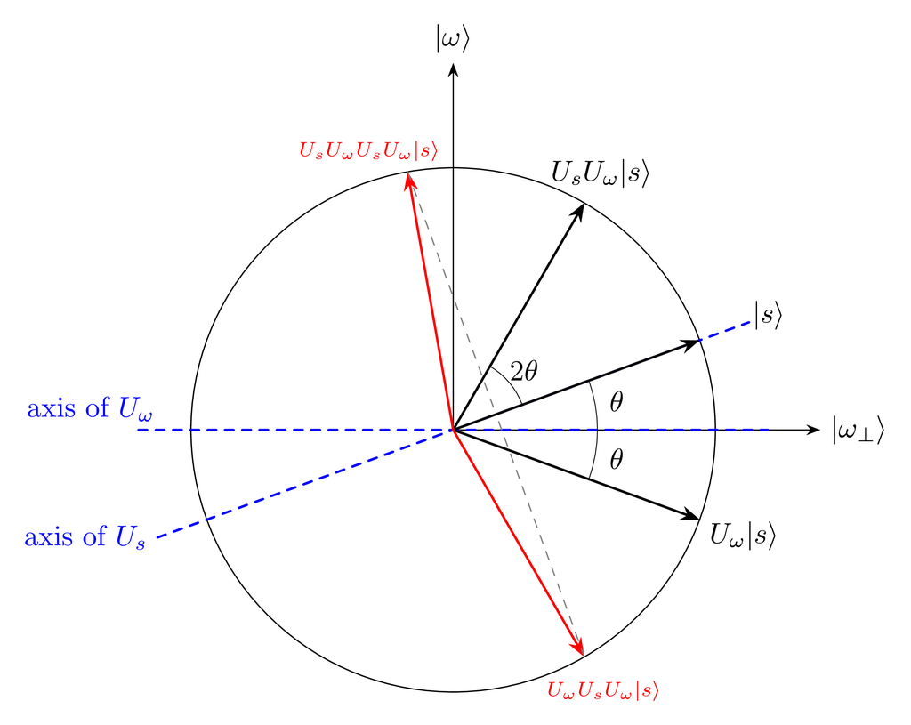

This concludes the single–marked-item case of Grover's algorithm.

### Grover's Algorithm Beyond the Single-Marked Case

Next, we present a simple generalization that covers all possibilities, from no marked items to all items marked, using the same two-dimensional framework. The formulas extend naturally.

Let $\Omega \subseteq \{0, \dots, N-1\}$ denote the set of marked elements, with $|\Omega| = M$ satisfying $M \notin \{0, N\}$. Define an orthonormal basis of the invariant two–dimensional subspace $$ |\Omega \rangle = \frac{1}{\sqrt{M}} \sum_{x \in \Omega} |x\rangle, \qquad |R\rangle = \frac{1}{\sqrt{N-M}} \sum_{x \notin \Omega} |x\rangle. $$

The uniform superposition decomposes as $$ |s\rangle = \frac{1}{\sqrt{N}} \sum_x |x\rangle = \sin\theta\,|\Omega\rangle + \cos\theta\,|R\rangle, $$ where $$ \sin\theta = \sqrt{\frac{M}{N}}, \qquad \cos\theta = \sqrt{\frac{N-M}{N}}. $$

Since the subspace $\mathcal{S} = \operatorname{span}\{|\Omega\rangle, |R\rangle\}$ is invariant, compression via $\Pi_{\mathcal S} = |\Omega\rangle\langle\Omega| + |R\rangle\langle R|$ yields $$ U_\omega|_{\mathcal S} = \begin{pmatrix} -1 & 0\\ 0 & 1 \end{pmatrix}, \qquad U_s|_{\mathcal S} = \begin{pmatrix} -\cos(2\theta) & \sin(2\theta)\\ \sin(2\theta) & \cos(2\theta) \end{pmatrix}, $$ and therefore $$ G|_{\mathcal S} = U_s|_{\mathcal S} U_\omega|_{\mathcal S} = \begin{pmatrix} \cos(2\theta) & \sin(2\theta)\\ -\sin(2\theta) & \cos(2\theta) \end{pmatrix} = \operatorname{Rot}(2\theta). $$

After $k$ Grover iterations, $$ G^k|s\rangle = \sin\!\big((2k+1)\theta\big)\,|\Omega\rangle + \cos\!\big((2k+1)\theta\big)\,|R\rangle. $$

The success probability is $$ p_k = \|\Pi_\Omega G^k|s\rangle\|^2 = \sin^2\!\big((2k+1)\theta\big). $$

The continuous optimizer satisfies $(2k^\star + 1)\theta = \tfrac{\pi}{2}$, so $$ k^\star = \frac{\pi}{4\theta} - \frac{1}{2} \approx \frac{\pi}{4}\sqrt{\frac{N}{M}} - \frac{1}{2}, \qquad \left(\theta = \arcsin\!\sqrt{\frac{M}{N}} \approx \sqrt{\frac{M}{N}}\right). $$

Thus, the number of Grover iterations is chosen as the nearest integer to $k^\star$: $$ k_{\text{opt}} = \operatorname{round}\!\left( \frac{\pi}{4}\sqrt{\frac{N}{M}} - \frac{1}{2} \right), $$ leading to query complexity $$ \mathcal{O}\!\left(\sqrt{\frac{N}{M}}\right). $$

If $M = 0$, meaning no marked states exist in the search space, or $M = N$, meaning every state is marked, then the oracle acts trivially on the uniform superposition: $$ U_\omega|_{\mathcal S}\,|s\rangle = \begin{cases} +|s\rangle, & M = 0,\\[6pt] -|s\rangle, & M = N. \end{cases} $$

Applying the diffuser gives $$ \pm\, U_s|_{\mathcal S}\,|s\rangle = \pm\big(2|s\rangle\langle s| - I_{\mathcal S}\big)|s\rangle = \pm (2|s\rangle - |s\rangle) = \pm |s\rangle, $$ and therefore $$ G|s\rangle = U_s U_\omega |s\rangle = \pm |s\rangle. $$

Thus, in both extreme cases the Grover iteration produces no nontrivial amplitude amplification:

- **Case $M=0$ (no solutions):** the state remains the uniform superposition; measurement yields each computational basis state with probability $1/2^n$.
- **Case $M=N$ (all solutions):** the state is already entirely within the marked subspace; measurement always returns a marked element with certainty.

With inspection it can easily be verifeid whether all the states are marked or non appear in the search space.

Note that when $1 < M < N$, Grover's algorithm does not return all marked states simultaneously; rather, each execution returns one marked state sampled almost uniformly from the $M$-element marked set. To find all marked states, one can rerun Grover’s algorithm multiple times, but this may be inefficient because later runs may yield solutions that were already found.

In principle, if the oracle could be modified after each discovery so that previously found states are no longer marked, then each subsequent run of Grover's algorithm would return a new unique solution. However, in the standard oracle model the oracle is immutable and cannot be altered.

An alternative is to apply additional unitaries after each oracle call to cancel its phase flip on already-discovered states, effectively simulating a modified oracle. Regardless of the method, it is important to understand that Grover’s algorithm returns a single marked element per run, drawn from the marked set, and its results must be interpreted accordingly.

### Estimating the Number of Solutions

Note that, so far, we have discussed finding marked states under the assumption that $M$ is known. In practice, the number of marked items may not be given in advance, yet Grover's algorithm depends on $M$ to determine the optimal number of iterations. Estimating $M$ therefore becomes an important preliminary task.

One systematic approach is the [quantum counting algorithm](https://en.wikipedia.org/wiki/Quantum_counting_algorithm), which combines Quantum Phase Estimation with Grover's operator to obtain a probabilistic estimate of $M$. Other estimation techniques exist, including classical sampling and probabilistic methods, but quantum counting provides a natural quantum extension of Grover's search.

### Optimality of Query Complexity

We have shown that Grover's algorithm solves the unstructured search problem in $\mathcal{O}(\sqrt{N})$ queries asymptotically. A natural question to ask is whether we can do better than that.

In fact, a paper by Charles Bennett, Ethan Bernstein, Gilles Brassard, and Umesh Vazirani, titled [*Strengths and Weaknesses of Quantum Computing*](https://arxiv.org/abs/quant-ph/9701001), showed that $\mathcal{O}(\sqrt{N})$ is tight. That is, any quantum algorithm for solving the unstructured search problem is bounded below by $\Omega(\sqrt{N})$, hence the query complexity of the unstructured search problem using a quantum computer is in $\Theta(\sqrt{N})$.

Beyond showing that Grover's algorithm cannot be improved, this result has important theoretical implications. The fact that the unstructured search problem is bounded by $\sqrt{N}$ strengthens the conjecture that $\mathrm{NP} \not\subseteq \mathrm{BQP}$. The speedup achieved by quantum algorithms for such problems is not superpolynomial. The optimality result suggests that while quantum computers are powerful in some instances, for *unstructured search problems* there exists a fundamental bound on the achievable quantum speedup.

### Comparison of Query Complexity of Classical and Quantum Methods

The classical complexity of the unstructured search problem grows linearly with the number of items in the search space $N$, and on average it takes $\tfrac{N}{2}$ queries to find the marked state, assuming $M = 1$.

With $N = 2^n$, the classical algorithm is bounded by $\mathcal{O}(N) = \mathcal{O}\!\left(\tfrac{2^n}{2}\right) = \mathcal{O}(2^n)$, whereas Grover’s algorithm achieves quantum query complexity $\mathcal{O}(\sqrt{N}) = \mathcal{O}(2^{\frac{n}{2}})$. Thus, a quantum computer does not provide an exponential speedup for unstructured search, but rather a quadratic speedup over the classical case.

### Grover's Algorithm: Implementation and State Evolution in Qiskit and PennyLane

Next, we implement a 3-qubit version of Grover's algorithm in Qiskit and PennyLane, with the marked item being `011`. Creating the oracle unitary that flips the phase of only the marked item is not a trivial task, and we will first discuss a few **incorrect approaches** that help build intuition before gradually working our way toward a correct implementation of the Grover oracle operator. It is worth noting that the [`PhaseOracleGate`](https://quantum.cloud.ibm.com/docs/en/api/qiskit/qiskit.circuit.library.PhaseOracleGate) class in Qiskit and the [`FlipSign`](https://docs.pennylane.ai/en/stable/code/api/pennylane.FlipSign.html) operator in PennyLane both perform a phase flip on a chosen computational-basis state and serve as natural ways to construct the oracle. For the purposes of this tutorial, however, we will explicitly build an equivalent operator by masking the 0-bits of the target state using `X` gates, applying a multi-controlled phase (e.g., `CCZ` for 3 qubits), and then unmasking, achieving the same phase inversion effect required by Grover's algorithm.

**Implementing Grover's Algorithm in Qiskit**

We then implement tools to track the probability of the marked state throughout the evolution of Grover's algorithm and generate visualizations to verify compatibility with the analytical formulation. This ensures that the theoretical predictions of Grover's amplitude amplification align closely with the observed implementation in practice.

**Incorrect approach 1**

We would like to create a unitary that sends the basis state $|011\rangle \mapsto -|011 \rangle$, while keeping all the other computational basis states intact. Suppose we have already applied $|s\rangle = H^{\otimes 3} |000\rangle$ to create a uniform superposition of all basis states.  
Since $Z|0\rangle = |0\rangle$ and $Z|1\rangle = -|1\rangle$, one simplistic idea is to transform the $|0\rangle$ states to $|1\rangle$ by applying $X$ gates, and then apply $Z^{\otimes 2}$ on the last two wires. Hence, the proposed operation is:

$$ U = (I \otimes Z^{\otimes 2}) \circ (I \otimes X^{\otimes 2}), $$

and we apply it to the uniform superposition $|s\rangle$:

$$ U_{\text{incorrect}} |s\rangle = (I \otimes Z^{\otimes 2}) (I \otimes X^{\otimes 2}) |s\rangle. $$

There are two issues with this approach. First, applying two $Z$ gates introduces two phase flips, so the sign of $|011\rangle$ remains positive at the end of this procedure.

The second issue is that $|s\rangle$ is a superposition of all computational basis states $\{|000\rangle, |001\rangle, \ldots, |111\rangle\}$.  
Hence, applying $(I \otimes Z^{\otimes 2}) \circ (I \otimes X^{\otimes 2})$ yields:

$$ U_{\text{incorrect}} |s\rangle = \frac{1}{\sqrt{8}} \left( |000\rangle - |001\rangle - |010\rangle + |011\rangle + |100\rangle - |101\rangle - |110\rangle + |111\rangle \right). $$

As we can see, the intended state $|011\rangle$ remains unflipped, while the states $\{|001\rangle, |010\rangle, |101\rangle, |110\rangle\}$ have their signs flipped, which was not the intention.

**Incorrect approach 2**

Fixing the first issue in the above proposed solution is simple. One can apply one $Z$ gate as opposed to two $Z$ gates. For instance $(I \otimes Z \otimes I) \circ (I \otimes X^{\otimes 2})$ or $(I \otimes I \otimes Z) \circ (I \otimes X^{\otimes 2})$ both ensure that the sign of $|011\rangle$ is flipped once, correctly producing $-|011\rangle$ in the output. However, even this approach does not address the second issue, that is flipping the sign of other computational states which should remain intact. For instance, if we apply $(I \otimes Z \otimes I) \circ (I \otimes X^{\otimes 2})$ onto $|s\rangle$, the resulting state is:

$$ \frac{1}{\sqrt{8}} \left( |000\rangle + |001\rangle - |010\rangle - |011\rangle + |100\rangle + |101\rangle - |110\rangle - |111\rangle \right), $$

which shows the states $\{ |010\rangle, |011\rangle, |110\rangle, |111\rangle \}$ (those with middle qubit $=1$) all have changed signs. Thus, although $|011\rangle$ is flipped, this construction still fails to isolate and flip only the target state.

**Correct approach**

The main insight from the previous two incorrect approaches is that we need finer control over which computational state receives the phase flip. To ensure that only the target basis state acquires a negative sign, while all other states remain unchanged, we must introduce controlled unitaries that condition the phase operation on the exact bit pattern of the target. This selective control allows the oracle to implement the transformation $|x\rangle \mapsto -|x\rangle$ for the marked state, without disturbing the rest of the superposition.

To achieve this, we use a mask-flip-unmask strategy that isolates the target state without disturbing the rest of the superposition.

The idea is simple:

1. **Masking**: We first apply $X$ gates on all qubits that are 0 in the target bitstring. This effectively maps the desired target state (for example, $|011\rangle$) into the all-ones state $|111\rangle$. As a result, only the marked basis state is transformed to the all-ones state, while every other basis state is mapped somewhere else.
2. **Phase flip**: We then apply a multi-controlled $Z$ gate, which flips the phase of the marked state (for example, $|111\rangle$) and leaves all other states unchanged. Since only the masked target corresponds to the all-ones state, it is the only one that acquires a negative sign.
3. **Unmasking**: Finally, we reverse the initial masking by applying the same $X$ gates again. This restores all the basis states to their original form, but now the target state retains its flipped sign.

In this way, the circuit ensures that only the intended computational basis state (the "marked" item) has its phase inverted, while every other state in the superposition remains exactly as it was.

From an implementation point of view, Qiskit provides 2.x provides a native, high-level way to implement Grover oracle directly from Boolean expressions using the [`PhaseOracleGate`](https://quantum.cloud.ibm.com/docs/en/api/qiskit/qiskit.circuit.library.PhaseOracleGate) class. For example, the expression

```python
from qiskit.circuit.library import PhaseOracleGate
oracle = PhaseOracleGate("(q0 & q1 & ~q2)")
```

automatically constructs a phase oracle that flips the phase of the state $|011\rangle$.

However, for educational and structural clarity, this tutorial implements the oracle explicitly using the mask-flip-unmask strategy.

Qiskit provides a built-in implementation of the multi-controlled X gate through the [`MCXGate`](https://quantum.cloud.ibm.com/docs/en/api/qiskit/qiskit.circuit.library.MCXGate) class.  
It is important to distinguish between the `MCXGate` class, which defines the gate itself, and the [`mcx`](https://quantum.cloud.ibm.com/docs/en/api/qiskit/qiskit.circuit.QuantumCircuit#mcx) method of `QuantumCircuit`, which simply constructs and appends an `MCXGate` to the circuit. According to the documentation:

> `qiskit.circuit.quantumcircuit.QuantumCircuit.mcx()`’s argument `mode` is deprecated as of Qiskit 2.1. It will be removed no earlier than 3 months after the release date. Instead, add a generic `MCXGate` to the circuit and specify the synthesis method via the `hls_config` in transpilation. Alternatively, specific decompositions are available at https://qisk.it/mcx.

Thus, while `mcx()` itself remains supported, its `mode` argument is deprecated.

Although Qiskit also allows the creation of multi-controlled $Z$ operations using [`ZGate().control(num_ctrl_qubits)`](https://quantum.cloud.ibm.com/docs/en/api/qiskit/qiskit.circuit.library.ZGate#control), this is not a native gate class. There is no dedicated "MCZGate". For the purposes of this tutorial, the multi-controlled $Z$ operation is implemented by leveraging the equivalence $Z = H X H$ and surrounding an `MCXGate` with Hadamard gates on the target qubit. This `H-MCX-H` construction is the preferred method.

### Proof that the oracle equals $I - 2\,|x\rangle\langle x|$

Let the marked bitstring be $x=t\in\{0,1\}^n$. Define the mask $$ M_t \;=\; \bigotimes_{i=1}^n X^{1-t_i}, $$ so that $M_t\,|t\rangle = |1^n\rangle$ and $M_t$ is Hermitian and involutory: $M_t^\dagger=M_t$, $M_t^2=I$.

Let the core phase operation be $$ F_Z \;=\; H_{n}\ \mathrm{MCX}_{[1,\dots,n-1]\to n}\ H_{n}. $$ That is, Hadamard on the last qubit, then a multi-controlled $X$ with the first $n-1$ qubits as controls and the last as target, then Hadamard on the last qubit again. (Any choice of target qubit works; we pick the last for definiteness.)

#### Step 1: $F_Z$ is a projector phase on $|1^n\rangle$

Use the single-qubit identity $Z = H X H$. Conjugating a controlled-$X$ by $H$ on the target converts it to a controlled-$Z$ on that target.  
Since the controls are the first $n-1$ wires, $\mathrm{MCX}$ fires if and only if those controls are all $|1\rangle$. Therefore,

- $F_Z$ acts as $Z$ on the last qubit if and only if the state is $|11\ldots 1\rangle$, and
- $F_Z$ acts as identity otherwise.

Hence $$ F_Z \;=\; I \;-\; 2\,|1^n\rangle\langle 1^n|. $$

In other words, $F_Z|y\rangle = -|y\rangle$ if $y=1^n$, and $F_Z|y\rangle=|y\rangle$ otherwise. This is exactly the action of $I-2|1^n\rangle\langle 1^n|$.

#### Step 2: Conjugate by the mask

The implemented oracle is $$ U \;=\; M_t\,F_Z\,M_t. $$ Using $M_t\,|t\rangle = |1^n\rangle$ and $M_t^\dagger=M_t$, $$ \begin{aligned} U &= M_t\bigl(I - 2\,|1^n\rangle\langle 1^n|\bigr)M_t = I - 2\,M_t|1^n\rangle\langle 1^n|M_t \\ &= I - 2\,|t\rangle\langle t|. \end{aligned} $$ Thus the mask-$(H-\mathrm{MCX}-H)$-unmask construction exactly equals the ideal Grover oracle $I - 2\,|x\rangle\langle x|$.

#### 3-qubit check for $t=011$

- Mask: $M_{011}=X\otimes I\otimes I$ sends $|011\rangle\mapsto|111\rangle$.
- $F_Z$ flips the phase of $|111\rangle$ only.
- Unmask: apply $X\otimes I\otimes I$ again.

Therefore $U|011\rangle=-|011\rangle$ and $U|y\rangle=|y\rangle$ for $y\neq 011$. It implies $U=I-2\,|011\rangle\langle 011|$.

Now we have all the ingredients to implement Grover's oracle in Qiskit.

```python
from qiskit import QuantumCircuit

def grover_oracle(bitstring):
    """
    build Grover's oracle for a given bitstring.
    Uses mask-(H-MCX-H)-unmask construction, where H-MCX-H is equivalent to multi-controlled Z operation.
    """
    n = len(bitstring)
    qc = QuantumCircuit(n)

    # Mask: transfrom the marked state to the all-one state |11...1>
    for i, b in enumerate(reversed(bitstring)): # map bitstring[q_{n-1}..q0] to wires [n-1..0]
        if b == "0":
            qc.x(i)

    # Multi-controlled Z: implement as H-CC...CX-H on the last wire
    target = n-1
    if n == 1:
        qc.z(0)
    else:
        controls = [wire for wire in range(n) if wire != target] # all wires act as control except for the target
        qc.h(target)
        qc.mcx(controls, target) # CC...CX
        qc.h(target)

    # Unmask
    for i, b in enumerate(reversed(bitstring)):
        if b == '0':
            qc.x(i)

    return qc
```

Next, we verify numerically that the unitary created by the `grover_oracle` function is equivalent to $I - 2|x\rangle \langle x|$ and the oracle generated from the `PhaseOracleGate` seen above. With the marked state being `011`, and $|011\rangle\langle 011|$ being a matrix with a single $1$ at entry $(3,3)$ (since $0\times2^2 + 1\times2^1 + 1\times2^0 = 3$, using zero-based indexing so $(3,3)$ corresponds to the fourth row and column) and zeros elsewhere, we obtain

$$ I - 2|011\rangle\langle 011| = \operatorname{diag}(1,\,1,\,1,\,-1,\,1,\,1,\,1,\,1). $$

```python
from qiskit.quantum_info import Operator
import numpy as np

bitstring = "011"
oracle_circ = grover_oracle(bitstring)
U_oracle_constructed = Operator(oracle_circ).data

# constructing I - 2|x><x|
n = len(bitstring)
dim = 2**n
idx = int(bitstring, 2)
U_oracle_direct = np.eye(dim, dtype=complex)
U_oracle_direct[idx, idx] -= 2  # diag(1,1,1,-1,1,1,1,1)

print("Matches I - 2|x><x|?", np.allclose(U_oracle_constructed, U_oracle_direct, atol=1e-12))

# using PhaseOracleGate
U = Operator(PhaseOracleGate("(q0 & q1 & ~q2)").definition).data
print("Matches Qiskit's PhaseOracleGate?", np.allclose(U_oracle_constructed, U, atol=1e-12))
```

```
Matches I - 2|x><x|? True
Matches Qiskit's PhaseOracleGate? True
```

Next, we will implement Grover's search algorithm using built-in functions provided by Qiskit. We also need to compute the optimal number of running Grover's algorithm, which can be computed by $k_{\text{opt}}=\operatorname{round}\!\left(\frac{\pi}{4}\sqrt N - \frac12\right)$, with $N=2^3$.

```python
k_opt = int(np.round(np.pi/4*np.sqrt(8)-1/2))
print(np.pi/4*np.sqrt(8)-1/2, "\t", k_opt)
```

```
1.721441469079183 	 2
```

Qiskit includes a native implementation of Grover's algorithm in the `qiskit_algorithms` library, which introduces two relevant classes: `AmplificationProblem` and `Grover`.

The [`AmplificationProblem`](https://qiskit-community.github.io/qiskit-algorithms/stubs/qiskit_algorithms.AmplificationProblem.html) class defines the problem specification for amplitude amplification. It encapsulates the oracle, the state preparation routine, the list of "good" states, and any optional post-processing applied to the resulting bitstring. In Qiskit's own words:

> The amplification problem is the input to amplitude amplification algorithms, like Grover.  
> This class contains all problem-specific information required to run an amplitude amplification algorithm.  
> It minimally contains the Grover operator. It can further hold some post processing on the optimal bitstring.

The [`Grover`](https://qiskit-community.github.io/qiskit-algorithms/stubs/qiskit_algorithms.Grover.html) class performs the execution of the algorithm. It constructs the Grover operator, applies it for a specified number of iterations, and uses a sampler such as `StatevectorSampler` or `AerSampler` to evaluate or simulate the circuit. The resulting object reports both the most probable measurement outcome and a flag indicating whether a "good" state was found. As described in the documentation:

> Grover's Search ... is a well known quantum algorithm that can be used for searching through unstructured collections of records for particular targets with quadratic speedup compared to classical algorithms...
> With the given oracle, Grover's Search constructs the Grover operator to amplify the amplitudes of the good states
> $$\mathcal{Q} = H^{\otimes n} \mathcal{S}_0 H^{\otimes n} \mathcal{S}_f = D \mathcal{S}_f,$$
> where $\mathcal{S}_0$ flips the phase of the all-zero state and acts as identity on all other states. Sometimes the first three operands are summarized as diffusion operator, which implements a reflection over the equal superposition state...
> The generalization of Grover's Search, Quantum Amplitude Amplification [3], uses a modified version of $\mathcal{Q}$ where the diffusion operator does not reflect about the equal superposition state, but another state specified via an operator $\mathcal{A}$:
> $$\mathcal{Q} = \mathcal{A} \mathcal{S}_0 \mathcal{A}^\dagger \mathcal{S}_f.$$

Note the documentation itself hints at the close conceptual connection between Grover's search and quantum amplitude amplification. However, quantum amplitude amplification is beyond the scope of this tutorial and will not be covered here.

```python
# Import Grover's algorithm and problem-specification classes
from qiskit_algorithms import Grover, AmplificationProblem

# Import a "Sampler" primitive: it evaluates measurement probabilities.
# StatevectorSampler gives exact theoretical probabilities (no shot noise);
# AerSampler (optional) simulates shot-based measurements.
from qiskit.primitives import StatevectorSampler

# Define the amplitude amplification problem
# - oracle_circ: a quantum circuit that flips the phase of the "good" state(s)
# - is_good_state: defines which bitstrings count as a successful outcome
# Nothing runs yet — this only describes the problem to solve.
problem = AmplificationProblem(oracle_circ, is_good_state=['011'])

# Configure the Grover algorithm runner
# - sampler: tells Grover how to evaluate circuits (statevector or hardware)
# - iterations: number of Grover iterations (k_opt if computed optimally)
# This just sets up the algorithm object; still no execution.
grover = Grover(sampler=StatevectorSampler(), iterations=k_opt)

# Execute the algorithm on the defined problem
# This is where Grover and the problem "talk":
# - Builds the full Grover operator Q = A S0 A* Sf
# - Applies Q the specified number of times
# - Uses the sampler to obtain measurement results
# - Returns a GroverResult object containing analysis and metadata
result = grover.amplify(problem)

# Interpret the results
# result.oracle_evaluation -> Boolean indicating if the top bitstring is a "good" state
# result.top_measurement   -> The most probable bitstring observed
print("Success!" if result.oracle_evaluation else "Failure!")
print("Top measurement:", result.top_measurement)  # should be '011'
```

```
Success!
Top measurement: 011
```

Note that Qiskit provides a built-in method in the `Grover` class to determine the optimal number of iterations, given by [`optimal_num_iterations(num_solutions=M, num_qubits=n)`](https://qiskit-community.github.io/qiskit-algorithms/_modules/qiskit_algorithms/amplitude_amplifiers/grover.html#Grover.optimal_num_iterations). This method requires specifying the number of solutions `M` and the number of qubits `n`.

```python
Grover.optimal_num_iterations(num_solutions=1, num_qubits=3)
```

```
2
```

We can visualize the circuit corresponding to the Grover operator using  
`problem.grover_operator.decompose().draw('mpl')`, a method available on the `AmplificationProblem` object through its `grover_operator` attribute.  
Note that calling `.decompose()` expands composite gates, such as multi-controlled gates or subcircuits, into their lower-level basis gates. As a result, the displayed circuit may not exactly match how the gates were originally implemented in the high-level oracle definition.

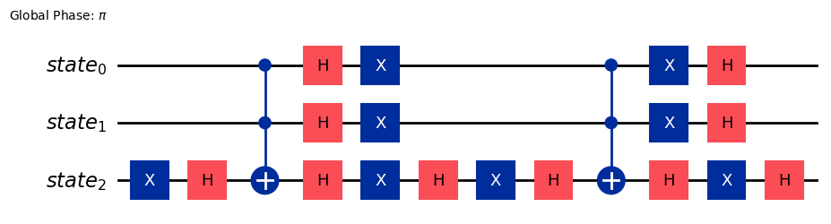

```python
problem.grover_operator.decompose().draw('mpl')
```

One limitation of using Qiskit’s built-in Grover implementation, although convenient, is that it offers limited control and visibility over how the state probabilities evolve during the algorithm's execution. To observe how the probability distribution changes after each Grover iteration, we need to define the circuit at a lower level and manually track its intermediate states. This allows us to visualize how the amplitudes are amplified step by step and verify that the evolution matches our theoretical intuition.

To construct the Grover diffuser $D = H^{\otimes n} \,(2|0\rangle\langle 0| - I)\, H^{\otimes n}$, we use a similar *mask–phase-flip–unmask* idea as in the oracle: we first map $\lvert 0^n\rangle$ to $\lvert 1^n\rangle$, apply a multi-controlled phase flip on that state, and then undo the transformation.

$$ D = H^{\otimes n} \, X^{\otimes n} \, (I - 2\lvert 11\dots1\rangle\!\langle 11\dots1\rvert) \, X^{\otimes n} \, H^{\otimes n} = 2\lvert s\rangle\!\langle s\rvert - I, \qquad \text{where } \lvert s\rangle = H^{\otimes n}\lvert 0\rangle^{\otimes n}. $$

Below is a generalized diffuser that works for any number of qubits:

```python
def grover_diffuser(num_qubits):
    """
    Construct an n-qubit Grover diffuser implementing 2|s><s| - I,
    where |s> is the uniform superposition state.

    Args:
        num_qubits: Number of qubits in the search register.

    Returns:
        QuantumCircuit: The diffuser circuit.
    """
    qc = QuantumCircuit(num_qubits)
    # Apply Hadamard to all qubits to move to the |s> basis
    qc.h(range(num_qubits))

    # Apply X to all qubits to map |0...0> -> |1...1>
    qc.x(range(num_qubits))

    # Perform a multi-controlled Z on |11...1>
    target = num_qubits - 1
    qc.h(target)
    qc.mcx(list(range(num_qubits - 1)), target)
    qc.h(target)

    # Undo the X and Hadamard layers to return to the original basis
    qc.x(range(num_qubits))
    qc.h(range(num_qubits))

    return qc
```

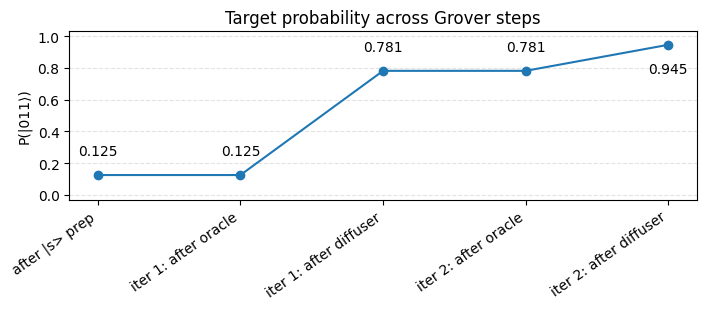

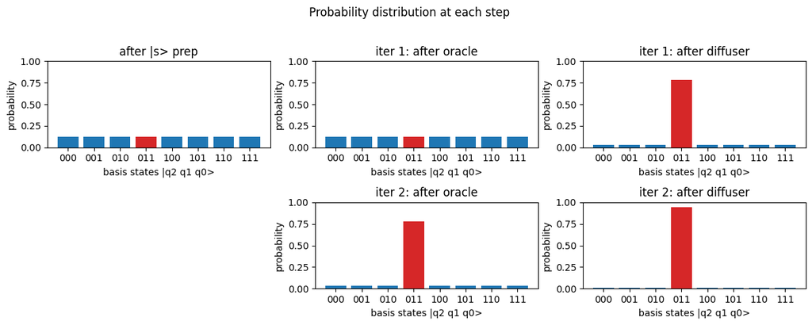

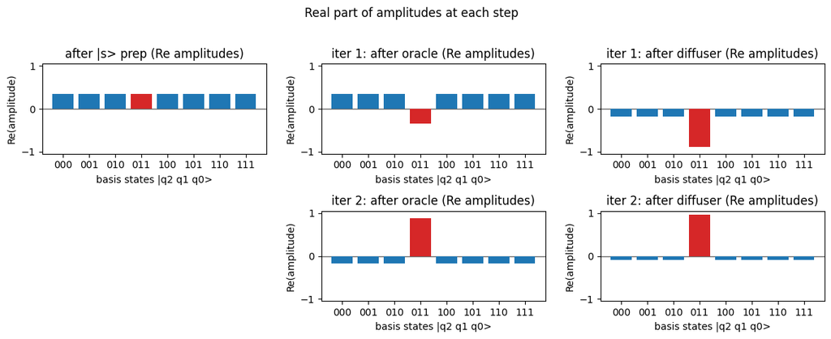

```python
# --- Grover evolution ---
from qiskit.quantum_info import Statevector
import matplotlib.pyplot as plt


# Parameters
n = 3
marked = "011"
oracle = grover_oracle(marked)
diffuser = grover_diffuser(n)

# --- Prepare |s> and collect snapshots
qc_prep = QuantumCircuit(n)
qc_prep.h(range(n))
sv = Statevector.from_instruction(qc_prep)

titles = ["after |s> prep"]
states = [sv]

for k in range(1, k_opt + 1):
    sv = sv.evolve(oracle)
    titles.append(f"iter {k}: after oracle")
    states.append(sv)

    sv = sv.evolve(diffuser)
    titles.append(f"iter {k}: after diffuser")
    states.append(sv)

# ---------------- Figure 1: target probability across steps ----------------
target_probs = [sv_i.probabilities_dict()[marked] for sv_i in states]
xs = np.arange(len(titles))

plt.figure(figsize=(7.2, 3.2))
plt.plot(xs, target_probs, marker="o", zorder=3)
for x, y in zip(xs, target_probs):
    dy = 0.15 if y <= 0.85 else -0.15
    y_txt = min(max(y + dy, 0.02), 0.98)
    plt.text(x, y_txt, f"{y:.3f}", ha="center", va="center")
plt.title("Target probability across Grover steps")
plt.xticks(xs, titles, rotation=35, ha="right")
plt.ylabel(f"P(|{marked}⟩)")
plt.ylim(-0.03, 1.03)
plt.grid(True, axis="y", linestyle="--", alpha=0.35)
plt.tight_layout()
plt.show()

# ---------------- Figure 2: probability distributions ----------------
fig, axes = plt.subplots(2, 3, figsize=(12, 5.0))

def plot_prob_bars(ax, sv_obj, title):
    p_dict = sv_obj.probabilities_dict()     # native labels + probabilities
    labels, probs = zip(*p_dict.items())
    colors = ["C0" if lbl != marked else "C3" for lbl in labels]
    ax.bar(labels, probs, color=colors)
    ax.set_ylim(0, 1.0)
    ax.set_title(title)
    ax.set_xlabel("basis states |q2 q1 q0>")
    ax.set_ylabel("probability")

# row 1: prep, iter1 oracle, iter1 diffuser
plot_prob_bars(axes[0, 0], states[0], titles[0])
i1_oracle_idx, i1_diffuse_idx = 1, 2
plot_prob_bars(axes[0, 1], states[i1_oracle_idx],  titles[i1_oracle_idx])
plot_prob_bars(axes[0, 2], states[i1_diffuse_idx], titles[i1_diffuse_idx])

# row 2: empty, iter2 oracle, iter2 diffuser
axes[1, 0].axis("off")
if k_opt >= 2:
    i2_oracle_idx, i2_diffuse_idx = 3, 4
    plot_prob_bars(axes[1, 1], states[i2_oracle_idx],  titles[i2_oracle_idx])
    plot_prob_bars(axes[1, 2], states[i2_diffuse_idx], titles[i2_diffuse_idx])
else:
    axes[1, 1].axis("off"); axes[1, 2].axis("off")

fig.suptitle("Probability distribution at each step", y=0.98)
plt.tight_layout(rect=[0, 0.03, 1, 0.96])
plt.show()

# ---------------- Figure 3: REAL amplitudes ----------------
fig, axes = plt.subplots(2, 3, figsize=(12, 5.0))

def plot_real_amp_bars(ax, sv_obj, title):
    amp_dict = sv_obj.to_dict()
    labels, amps = zip(*amp_dict.items())
    reals = [a.real for a in amps]

    # Draw the zero line *before* the bars and in neutral gray
    ax.axhline(0.0, color="black", linewidth=1.0, alpha=0.6, zorder=1)

    # Plot bars above that line (zorder=2)
    colors = ["tab:blue" if lbl != marked else "tab:red" for lbl in labels]
    ax.bar(labels, reals, color=colors, zorder=2)

    ax.set_ylim(-1.05, 1.05)
    ax.set_title(title + " (Re amplitudes)")
    ax.set_xlabel("basis states |q2 q1 q0>")
    ax.set_ylabel("Re(amplitude)")

# row 1: prep, iter1 oracle, iter1 diffuser
plot_real_amp_bars(axes[0, 0], states[0], titles[0])
plot_real_amp_bars(axes[0, 1], states[i1_oracle_idx],  titles[i1_oracle_idx])
plot_real_amp_bars(axes[0, 2], states[i1_diffuse_idx], titles[i1_diffuse_idx])

# row 2: empty, iter2 oracle, iter2 diffuser
axes[1, 0].axis("off")
if k_opt >= 2:
    plot_real_amp_bars(axes[1, 1], states[i2_oracle_idx],  titles[i2_oracle_idx])
    plot_real_amp_bars(axes[1, 2], states[i2_diffuse_idx], titles[i2_diffuse_idx])
else:
    axes[1, 1].axis("off"); axes[1, 2].axis("off")

fig.suptitle("Real part of amplitudes at each step", y=0.98)
plt.tight_layout(rect=[0, 0.03, 1, 0.96])
plt.show()
```

We observe several important trends in these plots. First, applying Grover's oracle does not change the probability distribution of the computational basis states, since it only flips the sign of the marked state's amplitude. This phase flip is invisible at the probability level but becomes evident when examining the real and imaginary components of the statevector amplitudes: the marked basis state acquires a negative real amplitude.

The diffuser then converts this phase difference into a change in probability amplitudes, increasing the probability of the marked state. In these figures, we visualize the first two iterations of Grover’s algorithm; after each iteration, the probability of observing the marked state increases. If we continued applying further iterations, the probability would eventually decrease and then rise again, reflecting the periodic nature of Grover’s amplitude amplification.

Next, we will track the evolution of the marked state in Grover's algorithm after each full iteration following the diffuser step.  
The following code block is adaptable and the number of qubits and iterations can vary, while the number of marked items remains fixed at 1.

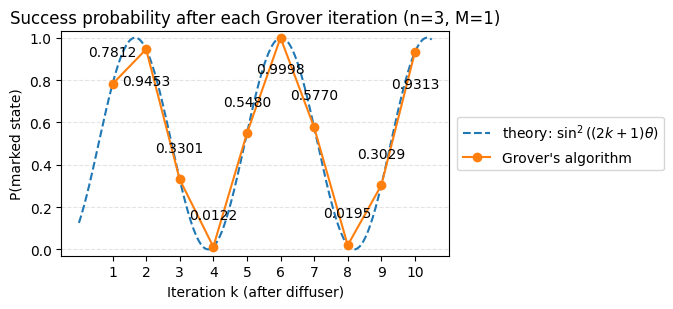

```python
# Grover success probability after each full iteration

# --- configurable ---
n = 3                 # number of qubits
num_iters = 10        # total Grover iterations
marked = '0'*(n-1) + '1'   # arbitrary marked state (M=1)

# --- components ---
oracle = grover_oracle(marked)
diffuser = grover_diffuser(n)

# prepare |s>
qc = QuantumCircuit(n)
qc.h(range(n))
sv = Statevector.from_instruction(qc)

# simulate probabilities after each full iteration
p_end_iter = []
for k in range(1, num_iters + 1):
    sv = sv.evolve(oracle)
    sv = sv.evolve(diffuser)
    p_end_iter.append(sv.probabilities_dict()[marked])

# theory
N = 2**n
theta = np.arcsin(1/np.sqrt(N))
k_vals = np.arange(1, num_iters + 1)
t = np.linspace(0, num_iters + 0.5, 800)
p_theory = np.sin((2*t + 1)*theta)**2

width = min(7 + 0.12*num_iters, 18)
fig, ax = plt.subplots(figsize=(width, 3.2))

# theory
ax.plot(t, p_theory, '--', label=r'theory: $\sin^2((2k+1)\theta)$')

# simulation
ax.plot(k_vals, p_end_iter, marker='o', label='Grover\'s algorithm')

# annotate points
for x, y in zip(k_vals, p_end_iter):
    dy = 0.15 if y <= 0.85 else -0.15
    y_txt = np.clip(y + dy, 0.02, 0.98)
    label_val = min(y, 0.9999)
    ax.text(x, y_txt, f"{label_val:.4f}", ha="center", va="center")

# axes
ax.set_title(f"Success probability after each Grover iteration (n={n}, M=1)")
ax.set_xlabel("Iteration k (after diffuser)")
ax.set_ylabel("P(marked state)")
ax.set_ylim(-0.03, 1.03)
ax.grid(True, axis='y', linestyle='--', alpha=0.35)

# adaptive x-ticks
step = max(1, num_iters // 10)
ax.set_xticks(k_vals[::step])
if k_vals[-1] not in k_vals[::step]:
    ax.set_xticks(list(ax.get_xticks()) + [k_vals[-1]])

# legend
ax.legend(loc='center left', bbox_to_anchor=(1.02, 0.5), borderaxespad=0.)
fig.tight_layout(rect=[0, 0, 0.84, 1])

plt.show()
```

In the figure above with 3 qubits, the success probability predicted by Grover's algorithm at the end of each iteration appears as discrete points lying on the continuous curve of $\sin^2\!\left((2k+1)\theta\right)$.

An interesting observation is that while our earlier analysis gave $k_{\text{opt}} = 2$, the algorithm can in fact reach a slightly higher success probability at $k = 6$, where $P_{\text{success}}(k=2) \approx 0.9453$ and $P_{\text{success}}(k=6) \approx 0.9998$.  
Why, then, is $k_{\text{opt}}$ defined as 2? Because $k_{\text{opt}} = 2$ is the smallest integer that corresponds to a local maximum of the success probability, and it need not be a global maximum. As seen in the plot, the probability first increases, then decreases, and later rises again with further iterations. Thus, $k_{\text{opt}}$ represents the first optimal (local) integer value, rather than the global optimum. It is important to interpret and understand the output and claims of Grover's algorithm accordingly.

**Grover's Algorithm in PennyLane**

Finally, we will implement the same instance of Grover's algorithm in PennyLane to find the marked state `011`, and plot the evolution of its probability as before.

We will use the `qml.FlipSign` operator to construct both the oracle and the diffuser, and the [`qml.Snapshot`](https://docs.pennylane.ai/en/stable/code/api/pennylane.Snapshot.html) operator to capture intermediate statevectors during the algorithm's execution, which is possible since we are running a simulation. In practice, however, one cannot take a snapshot of a quantum circuit without disturbing the quantum state.

```python
import pennylane as qml

num_qubits = 3
wires = list(range(num_qubits))
marked_state = "011"

dev = qml.device("default.qubit", wires = wires)

def pl_grover_oracle():
    qml.FlipSign([int(i) for i in marked_state], wires = wires)

def pl_grover_diffuser():
    for wire in wires:
        qml.Hadamard(wire)
        qml.X(wire)
    qml.FlipSign([1] * num_qubits, wires=wires)
    for wire in wires:
        qml.X(wire)
        qml.Hadamard(wire)

@qml.qnode(dev)
def pl_grover_iterations(num_iteration):
    # prepare |s> = H^\otimes n |000>
    for wire in wires:
        qml.Hadamard(wires = wire)
    qml.Snapshot("after |s> prep")

    for i in range(num_iteration):
        pl_grover_oracle()
        qml.Snapshot(f"iter {i+1}: after oracle")

        pl_grover_diffuser()
        qml.Snapshot(f"iter {i+1}: after diffuser")

    return qml.state()
```

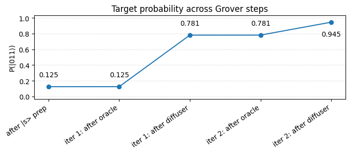

```python
snapshots = qml.snapshots(pl_grover_iterations)(2)

labels = [
    "after |s> prep",
    "iter 1: after oracle",
    "iter 1: after diffuser",
    "iter 2: after oracle",
    "iter 2: after diffuser",
]

# Extract statevectors from 'snapshots'
states = [np.asarray(snapshots[lbl]) for lbl in labels]

# Probability of the marked basis state |011⟩ (index 3)
target_idx = int(marked_state, 2)
target_probs = [float(np.abs(st[target_idx])**2) for st in states]

xs = np.arange(len(labels))

# Plot
plt.figure(figsize=(7.2, 3.2))
plt.plot(xs, target_probs, marker="o", zorder=3)
for x, y in zip(xs, target_probs):
    dy = 0.15 if y <= 0.85 else -0.15
    y_txt = min(max(y + dy, 0.02), 0.98)
    plt.text(x, y_txt, f"{y:.3f}", ha="center", va="center")
plt.title("Target probability across Grover steps")
plt.xticks(xs, labels, rotation=35, ha="right")
plt.ylabel(f"P(|{marked_state}⟩)")
plt.ylim(-0.03, 1.03)
plt.grid(True, axis="y", linestyle="--", alpha=0.35)
plt.tight_layout()
plt.show()
```

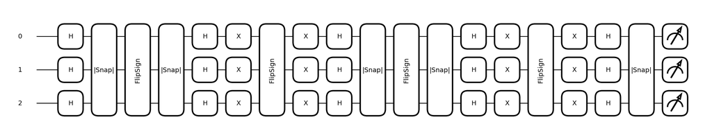

```python
qml.draw_mpl(pl_grover_iterations)(2)
plt.show()
```

### Conclusion

We introduced the unstructured search problem and Grover's search algorithm, a quantum algorithm that provides a quadratic speedup over its classical counterpart. Understanding Grover's algorithm required several mathematical tools such as invariant subspaces, compression and restriction, Householder reflections and related concepts. Once the geometric perspective is solidified, the overall structure of Grover's algorithm becomes more straightforward. The powerful technique is the creation of a rotation through two Householder reflections. Grover's framework also divides the solution space into good and bad states, which forms the basis of a broader family of quantum algorithms known as quantum amplitude amplification.

We then discussed how to determine the optimal number of Grover iterations. To do this, one must know the number of marked solutions, unless it is already provided as part of the problem description. There are methods for estimating this quantity, such as quantum counting, which uses quantum phase estimation to estimate the number of marked states.

We examined the query complexity of Grover's algorithm and its optimality in $\Theta(\sqrt{N})$. This has important implications for the limits of speedups that quantum algorithms can provide.

We also implemented Grover's algorithm in both Qiskit and PennyLane and constructed explicit circuits for the Grover oracle and the diffuser operator.

As it can be seen, Grover's algorithm has various components to it: understanding the analytical argument and correctness of the algorithm, determining the optimal number of iterations, and even determining the number of solutions. Interpreting the output of the algorithm is an important part of understanding Grover's algorithm.

Grover has other variants such as partial search, where one may be interested not in a specific item but in a category of items. See the paper titled [*Is partial quantum search of a database any easier?*](https://arxiv.org/abs/quant-ph/0407122v4) by Lov Grover and Jaikumar Radhakrishnan, which demonstrates that partial search still achieves a quantum speedup compared to classical methods.

Grover's algorithm also relies on a fixed oracle. In many real-world applications the oracle may not be given. Determining or approximating an oracle then becomes a problem in its own right.

Moreover, Grover Adaptive Search (GAS) can be used to solve optimization problems such as Constrained Polynomial Binary Optimization (CPBO), and Quadratic Unconstrained Binary Optimization (QUBO). See [*Grover Adaptive Search for Constrained Polynomial Binary Optimization*](https://arxiv.org/abs/1912.04088) by Austin Gilliam, Stefan Woerner and Constantin Gonciulea for details. More recent developments introduce Grover's search with a learning oracle (GLO), where a parameterized learning oracle is constructed through hybrid quantum-classical training. This learned oracle has been shown to reduce the number of expensive cost-function calls compared to plain GAS. See [*Grover’s search with learning oracle for constrained binary optimization problems*](https://link.springer.com/article/10.1007/s42484-024-00148-1) by Hiroshi Ohno for further information.

To summarize, Grover's algorithm is an important quantum algorithm, not only because of the speedup it provides compared to classical counterparts, but also because the techniques used in it are powerful and open the door to other variants, new algorithms and applications.

### Appendix 1: Biography

- Lov Grover was born in 1961 in Meerut, in northern India. He received his bachelor's degree from the Indian Institute of Technology Delhi in 1981 and completed his PhD in Electrical Engineering at Stanford University in 1985, with a dissertation titled [New concepts in free electron lasers](https://ui.adsabs.harvard.edu/abs/1985PhDT........18G/abstract). Grover later joined Bell Labs, where in 1996 he introduced what is now known as Grover's search algorithm in his paper [*A fast quantum mechanical algorithm for database search*](https://arxiv.org/abs/quant-ph/9605043). The operator that Grover referred to as the *inversion-about-average* operator, also called the diffuser operator, is one of the key breakthroughs and novelties of the algorithm. It is recognized as a Householder reflection. Together with Grover's oracle, it produces a rotation that enables the algorithm to amplify the probability of the marked state.

  It appears that Dr. Grover retired from [Bell Labs](https://datascience.columbia.edu/event/dr-lov-grover-is-quantum-searching-a-universal-property-of-nature/) in 2008. A talk by Dr. Grover titled *Is Quantum Searching a Universal Property of Nature?* is available on [YouTube](https://www.youtube.com/watch?v=zkg7eOqPs-o).

  A list of Dr. Grover’s publications can be found [here](https://dblp.org/pid/68/1541.html).

  As of January 2023, Dr. Grover joined Quantum Blockchain Technologies Plc, as noted in a statement released by the [company](https://quantumblockchaintechnologies.co.uk/images/QBT_-_RNS_-_RD_Update_Quantum_Computing_-_LKG.pdf) and reported by the [Quantum Insider](https://thequantuminsider.com/2023/01/09/quantum-pioneer-lov-kumar-grover-to-serve-as-consultant-to-quantum-blockchain-technologies/). In report by Quantum Insdier, he is described as "a special consultant for the theoretical assessment of the company’s proprietary quantum version of SHA-256, a quantum mining algorithm."
- Alston Scott Householder (1904-1993) was an American mathematician who made major contributions to modern numerical algebra. He introduced the [Householder transformation](https://dl.acm.org/doi/10.1145/320941.320947), which is used in core linear algebra applications such as [QR factorization](https://blogs.mathworks.com/cleve/2016/10/03/householder-reflections-and-the-qr-decomposition/). He also served as president of the Society for Industrial and Applied Mathematics (SIAM) and of the Association for Computing Machinery (ACM). Interestingly, the Householder transformation also appears in a quantum algorithm, Grover's algorithm.

### Appendix 2: References and Suggested Readings

1. Grover, Lov K. (1996). *A fast quantum mechanical algorithm for database search.* Published in: Proceedings of the 28th Annual ACM Symposium on Theory of Computing (STOC). DOI: https://dl.acm.org/doi/10.1145/237814.237866. [[arXiv](https://arxiv.org/abs/quant-ph/9605043)]
2. Nielsen, Michael A. & Chuang, Isaac L. (2010). *Quantum Computation and Quantum Information* (10th Anniversary Edition). Section 6: Quantum Search Algorithms.
3. IBM Quantum. *Grover’s Algorithm - Fundamentals of Quantum Algorithms.* Available at: https://quantum.cloud.ibm.com/learning/en/courses/fundamentals-of-quantum-algorithms/grover-algorithm/introduction
4. Microsoft Azure Quantum. *Theory of Grover's search algorithm.* Available at: https://learn.microsoft.com/en-us/azure/quantum/concepts-grovers
5. Botelho, Ludmila. *Grover's Algorithm.* PennyLane Demos. Available at: https://pennylane.ai/qml/demos/tutorial_grovers_algorithm
6. LaRose, Ryan. *Grover’s Search Algorithm (QuIC Seminar 5).* Available at: https://www.ryanlarose.com/uploads/1/1/5/8/115879647/grover.pdf
7. Watrous, John (2006). *Quantum Computation. Lecture 12: Grover’s Algorithm.* Available at: https://cs.uwaterloo.ca/~watrous/QC-notes/QC-notes.12.pdf
8. Watrous, John (2022). *Grover's Algorithm | Understanding Quantum Information & Computation | Lesson 08*. Published on the Qiskit YouTube channel. Available at: https://www.youtube.com/watch?v=hnpjC8WQVrQ&list=PLOFEBzvs-VvqKKMXX4vbi4EB1uaErFMSO
9. Boyer, Michel; Brassard, Gilles; Høyer, Peter; and Tapp, Alain (1996). *Tight bounds on quantum searching.* ACM reference: https://dl.acm.org/doi/10.5555/870802. [[arXiv](https://arxiv.org/abs/quant-ph/9605034)].
10. Brassard, Gilles; Høyer, Peter; Mosca, Michele; and Tapp, Alain (2000). *Quantum amplitude amplification and estimation.* [[arXiv](https://arxiv.org/abs/quant-ph/0005055)]
11. Gilliam, Austin; Woerner, Stefan; and Goncileea, Constantin (2021). *Grover adaptive search for constrained polynomial binary optimization.* Quantum, 5, 428. https://doi.org/10.22331/q-2021-04-08-428. [[arXiv](https://arxiv.org/abs/1912.04088)].
12. Ohno, H. (2024). *Grover’s search with learning oracle for constrained binary optimization problems.* Quantum Machine Intelligence, 6, 12. https://doi.org/10.1007/s42484-024-00148-1
13. Qiskit Community. *Grover Optimizer.* Available at: https://qiskit-community.github.io/qiskit-optimization/tutorials/04_grover_optimizer.html
14. Qiskit Community. *Maximum Likelihood Amplitude Estimation.* Available at: [https://qiskit-community.github.io/qiskit-\algorithms/stubs/qiskit_algorithms.MaximumLikelihoodAmplitudeEstimation.html](https://qiskit-community.github.io/qiskit-%5Calgorithms/stubs/qiskit_algorithms.MaximumLikelihoodAmplitudeEstimation.html)